# Содержание

- 1-Обзор данных
- 2-Предобработка данных
  - 2.1-Переименование столбцов
  - 2.2-Изменение типов данных
  - 2.3-Обработка пропущенных значений
  - 2.4-Обработка дубликатов
  - 2.5-Изучение столбцов с категориальными переменными: обработка неявных дубликатов
    - 2.5.1-Изучение столбца 'title'
    - 2.5.2-Изучение столбца 'type'
    - 2.5.3-Изучение столбца 'film_studio'
    - 2.5.4-Изучение столбца 'director'
    - 2.5.5-Изучение столбца 'producer'
    - 2.5.6-Изучение столбцов 'age_restriction','financing_source'
    - 2.5.7-Изучение столбцов 'production_country','genres'
  - 2.6-Изучение столбцов с количественными переменными: обработка аномальных значений
    - 2.6.1-Изучение столбца 'refundable_support'
    - 2.6.2-Изучение столбца 'nonrefundable_support'
    - 2.6.3-Изучение столбца 'budget'
    - 2.6.4-Изучение столбца 'box_office'
  - 2.7-Категоризация данных
- 3-Исследовательский анализ данных
  - 3.1-Анализ взаимосвязи между годом и выходом фильма в прокат
  - 3.2-Анализ изменения динамики проката по годам
  - 3.3-Анализ взаимосвязи между возрастным ограничением и сборами фильмов в прокате
  - 3.4-Исследование фильмов с государственной поддержкой
- 4-Общий вывод

# Исследование данных о российском кинопрокате

**Цель исследования** — выявить текущие тренды на рынке российского кинопроката.

**Для этого**:

- Изучим фильмы, которые вышли в прокат в России.
- Уделим внимание фильмам, которые получили государственную поддержку.
- Исследуем, насколько такие фильмы интересны зрителю.

**Описание данных**

В этом исследовании будут использованы данные, опубликованные на [портале открытых данных Министерства культуры](https://opendata.mkrf.ru). Набор данных содержит: информацию о прокатных удостоверениях, сборах и государственной поддержке фильмов, информацию с сайта "КиноПоиск".

Мы получим данные:

- О прокатных удостоверениях из файла `mkrf_movies.csv`. У одного фильма может быть несколько прокатных удостоверений;
- О прокате в российских кинотеатрах из файла `mkrf_shows.csv`.

Датафрейм `mkrf_movies` содержит следующие данные:

- `title` — название фильма
- `puNumber` — номер прокатного удостоверения
- `show_start_date` — дата премьеры фильма
- `type` — тип фильма
- `film_studio` — студия-производитель
- `production_country` — страна-производитель
- `director` — режиссёр
- `producer` — продюссер
- `age_restriction` — возрастная категория
- `refundable_support` — объём возвратных средств государственной поддержки
- `nonrefundable_support` — объём невозвратных средств государственной поддержки
- `financing_source` — источник государственного финансирования
- `budget` — общий бюджет фильма. Данные в этом столбце указаны только для тех фильмов, которые получили государственную поддержку
- `ratings` — рейтинг фильма на КиноПоиске
- `genres` — жанр фильма

Таблица `mkrf_shows` содержит следующие столбцы:

- `puNumber` — номер прокатного удостоверения
- `box_office` — сборы в рублях

**Ход исследования**

Перед исследованием потребуется обзор данных, так как отсутствует информация об их качестве. Проверим данные на наличие ошибок и исправим самые критичные ошибки на этапе предобработки.

Таким образом, исследование пройдёт в 3 этапа:

1. Обзор данных.

Ознакомимся с содержанием, структурой и характеристиками данных. Посмотрим, какие потенциальные проблемы могут быть в данных.

2. Предобработка данных.

Проведём более тщательную проверку на наличие ошибок и оценим их влияние.

3. Исследовательский анализ данных.

Используя обработанные данные, проведём анализ и определим тренды на рынке российского кинопроката и насколько зрителю интересны фильмы, получившие государственную поддержку.

## Обзор данных

Откроем файлы с данными:

```python
# импортируем библиотеку pandas
import pandas as pd
```

```python
# сохраним в переменную ссылку на первый датафрейм - mkrf_movies
mkrf_movies = pd.read_csv('https://code.s3.yandex.net/datasets/mkrf_movies.csv')
```

```python
# сохраним в переменную ссылку на втторой датафрейм - mkrf_shows в переменную
mkrf_shows = pd.read_csv('https://code.s3.yandex.net/datasets/mkrf_shows.csv')
```

Чтобы избежать ошибок при объединении двух датафреймов по значению столбца `puNumber`, убедимся, что в каждом из датафреймов этот столбец имеет одинаковый тип данных.

Ознакомимся с общей информацией датафреймов:

```python
# ознакомимся с общей информацией mkrf_movies
mkrf_movies.info()
```

```
<class 'pandas.core.frame.DataFrame'>
RangeIndex: 7486 entries, 0 to 7485
Data columns (total 15 columns):
 #   Column                 Non-Null Count  Dtype
---  ------                 --------------  -----
 0   title                  7486 non-null   object
 1   puNumber               7486 non-null   object
 2   show_start_date        7486 non-null   object
 3   type                   7486 non-null   object
 4   film_studio            7468 non-null   object
 5   production_country     7484 non-null   object
 6   director               7477 non-null   object
 7   producer               6918 non-null   object
 8   age_restriction        7486 non-null   object
 9   refundable_support     332 non-null    float64
 10  nonrefundable_support  332 non-null    float64
 11  budget                 332 non-null    float64
 12  financing_source       332 non-null    object
 13  ratings                6519 non-null   object
 14  genres                 6510 non-null   object
dtypes: float64(3), object(12)
memory usage: 877.4+ KB
```

```python
# ознакомимся с общей информацией mkrf_shows
mkrf_shows.info()
```

```
<class 'pandas.core.frame.DataFrame'>
RangeIndex: 3158 entries, 0 to 3157
Data columns (total 2 columns):
 #   Column      Non-Null Count  Dtype
---  ------      --------------  -----
 0   puNumber    3158 non-null   int64
 1   box_office  3158 non-null   float64
dtypes: float64(1), int64(1)
memory usage: 49.5 KB
```

В таблице `mkrf_movies` столбец `puNumber` принадлежит к типу данных **object**, в таблице `mkrf_shows` — к **int**. Приведём значения столбца в первом датафрейме к целочисленному типу:

```python
# приведём значения столбца к int с помощью to_numeric() и astype()
# с помощью dropna() удалим значение NA, появившееся после применения to_numeric() и errors='coerce'
mkrf_movies['puNumber'] = pd.to_numeric(mkrf_movies['puNumber'], errors='coerce').dropna().astype(int)

# проверим результат
mkrf_movies.info()
```

```
<class 'pandas.core.frame.DataFrame'>
RangeIndex: 7486 entries, 0 to 7485
Data columns (total 15 columns):
 #   Column                 Non-Null Count  Dtype
---  ------                 --------------  -----
 0   title                  7486 non-null   object
 1   puNumber               7485 non-null   float64
 2   show_start_date        7486 non-null   object
 3   type                   7486 non-null   object
 4   film_studio            7468 non-null   object
 5   production_country     7484 non-null   object
 6   director               7477 non-null   object
 7   producer               6918 non-null   object
 8   age_restriction        7486 non-null   object
 9   refundable_support     332 non-null    float64
 10  nonrefundable_support  332 non-null    float64
 11  budget                 332 non-null    float64
 12  financing_source       332 non-null    object
 13  ratings                6519 non-null   object
 14  genres                 6510 non-null   object
dtypes: float64(4), object(11)
memory usage: 877.4+ KB
```

Объединим таблицы `mkrf_movies` и `mkrf_shows`:

```python
# объединим таблицы по совпадению значений столбца puNumber
# с помощью параметра how='outer' объединим данные из внешней общей области
# сохраним результат в mkrf
mkrf = mkrf_movies.merge(mkrf_shows, on='puNumber', how='outer')

# выведем первые 20 строк новой таблицы и проверим результат
mkrf.head(20)
```

|  | title | puNumber | show_start_date | type | film_studio | production_country | director | producer | age_restriction | refundable_support | nonrefundable_support | budget | financing_source | ratings | genres | box_office |
| --- | --- | --- | --- | --- | --- | --- | --- | --- | --- | --- | --- | --- | --- | --- | --- | --- |
| 0 | 1001 рецепт влюбленного кулинара | 1811096.0 | 2010-12-23T12:00:00.000Z | Художественный | Ле Фильм дю Риваж, Ля Сет Синема, Адам и Ева, ... | Франция-Грузия-Германия-Россия-Украина-Бельгия | Н.Джорджадзе | NaN | «0+» - для любой зрительской аудитории | NaN | NaN | NaN | NaN | 6.7 | мелодрама,комедия | NaN |
| 1 | Небесный тихоход (новая цветная версия) | 111000110.0 | 2010-01-14T12:00:00.000Z | Художественный | Киностудия "Ленфильм", ЗАО "Киновидеообъединен... | СССР, Россия | И.Цветов (режиссер ч/б фильма - С.Тимошенко) | ЗАО "Киновидеообъединение "Крупный план" | «0+» - для любой зрительской аудитории | NaN | NaN | NaN | NaN | 8.0 | комедия,военный | NaN |
| 2 | И не было лучше брата | 111000111.0 | 2011-01-13T12:00:00.000Z | Художественный | ООО "Ибрус" при поддержке Киностудии "Азербай... | Россия - Азербайджан | М.Ибрагимбеков | М.Ибрагимбеков, А.Швыдкой, Д.Шуфутинский | «16+» - для детей старше 16 лет | NaN | NaN | NaN | NaN | 6.7 | детектив | NaN |
| 3 | Детский юмористический киножурнал "Ералаш", вы... | 111000112.0 | 2012-01-16T12:00:00.000Z | Художественный | ООО "Ералаш" | Россия | В.Панжев, Г.Курлаев, И.Белостоцкий, М.Сулейман... | ООО "Ералаш" | «0+» - для любой зрительской аудитории | NaN | NaN | NaN | NaN | 7.2 | детский,комедия | NaN |
| 4 | Тайна перевала Дятлова | 111000113.0 | 2013-01-17T12:00:00.000Z | Художественный | ООО "Нон-Стоп Продакшн" | Россия | Ренни Харлин | А.Роднянский, С.Мелькумов, С.Беспалов, Киа Джэм | «16+» - для детей старше 16 лет | NaN | NaN | NaN | NaN | 5.1 | ужасы,фантастика | 2.450000e+03 |
| 5 | Шагал-Малевич | 111000114.0 | 2014-01-13T12:00:00.000Z | Художественный | ООО "Мармот-фильм" | Россия | А.Митта | Л.Шнайдерман, А.Митта | «12+» - для детей старше 12 лет | NaN | NaN | NaN | NaN | 6.1 | биография,история | NaN |
| 6 | Небесный верблюд | 111000115.0 | 2015-01-14T12:00:00.000Z | Художественный | ООО Продюсерский центр "Всё хорошо" | Россия | Ю.Фетинг | И.Плиско | «0+» - для любой зрительской аудитории | 0.0 | 34000000.0 | 49280496.0 | Министерство культуры | 6.7 | детский,семейный | 6.104000e+04 |
| 7 | Статус: "Свободен" | 111000116.0 | 2016-01-13T12:00:00.000Z | Художественный | ООО "Кинодом" | Россия | П.Руминов | С.Ливнев, Д.Козловский, С.Бобза | «16+» - для детей старше 16 лет | 20000000.0 | 20000000.0 | 78686500.0 | Фонд кино | 5.8 | комедия,мелодрама | 1.530300e+08 |
| 8 | После тебя | 111000117.0 | 2017-01-10T12:00:00.000Z | Художественный | Компания Production Value WorldWide (ООО "ПРОД... | Россия | А.Матисон | С.Безруков | «16+» - для детей старше 16 лет | 7000000.0 | 20000000.0 | 45483233.0 | Министерство культуры, Фонд кино | 6.7 | драма | 1.226096e+07 |
| 9 | ЗОМБОЯЩИК (ZОМБОЯЩИК) | 111000118.0 | 2018-01-23T12:00:00.000Z | Художественный | ООО "Комеди Клаб продакшн" | Россия | З.Болотаев, К.Смирнов | Е.Казаков, Т.Бадзиев | «18+» - запрещено для детей | NaN | NaN | NaN | NaN | 3.2 | комедия | 1.636841e+08 |
| 10 | Пилигрим | 111000119.0 | 2019-02-14T12:00:00.000Z | Художественный | ООО "Чайка Синема" | Россия | А.Баршак | М.Гуцериев, Е.Север, Т.Стацман | «16+» - для детей старше 16 лет | 0.0 | 35000000.0 | 115000000.0 | Министерство культуры | 5.3 | триллер | 4.293650e+06 |
| 11 | День зверя | 111000210.0 | 2010-01-19T12:00:00.000Z | Художественный | ООО "Продюсерский центр "АМА" | Россия | М.Коновальчук | В.Малышев, А.Малышев | «12+» - для детей старше 12 лет | NaN | NaN | NaN | NaN | 6.6 | ужасы,комедия,фэнтези | NaN |
| 12 | Пропавший без вести. | 111000211.0 | 2011-01-13T12:00:00.000Z | Художественный | ООО " Пролайн Фильм" | Россия | А.Фенченко | А.Сигле, С.Ершов | «16+» - для детей старше 16 лет | NaN | NaN | NaN | NaN | 7.3 | драма,криминал,детектив | NaN |
| 13 | Ржевский против Наполеона | 111000212.0 | 2012-01-12T12:00:00.000Z | Художественный | ООО "Территория Кино" | Россия | М.Бальчунас | ООО "Квартал Леополис" | «16+» - для детей старше 16 лет | NaN | NaN | NaN | NaN | 3.0 | комедия | 2.000000e+02 |
| 14 | Шахта. | 111000213.0 | 2013-01-18T12:00:00.000Z | Художественный | ООО "Продюсерская компания Александра Литвинова | Россия | Н.Эген | А.Литвинов | «18+» - запрещено для детей | NaN | NaN | NaN | NaN | 8.0 | фантастика,боевик,драма | NaN |
| 15 | ПРАВО НА ЛЮБОВЬ | 111000214.0 | 2014-01-31T12:00:00.000Z | Художественный | ООО "Гравити Партнершип" | Россия | Д.Филюков | Н.Трынкин, Д.Филюков | «18+» - запрещено для детей | NaN | NaN | NaN | NaN | 7.5 | боевик,мелодрама | NaN |
| 16 | Библиотекарь. | 111000215.0 | 2015-01-14T12:00:00.000Z | Художественный | ООО "Россфильм" | Россия | Т.Воронецкая | Е.Белова | «16+» - для детей старше 16 лет | NaN | NaN | NaN | NaN | 6.7 | фэнтези,боевик,триллер | NaN |
| 17 | Городские птички. | 111000216.0 | 2016-01-15T12:00:00.000Z | Художественный | ООО "Каргофильм" | Россия | Ю.Белюсева | А.Готлиб | «16+» - для детей старше 16 лет | 0.0 | 25000000.0 | 38461538.0 | Министерство культуры | 5.4 | комедия,мелодрама | 3.555670e+05 |
| 18 | ЧУЖАЯ. | 111000217.0 | 2017-01-11T12:00:00.000Z | Художественный | ООО Кинокомпания "Фортуна Фильм", ООО "Центр Ю... | Россия | А.Васин, Г.Параджанов, О.Бородина | Э.Архангельская, А.Пискунова, Ф.Крат | «18+» - запрещено для детей | NaN | NaN | NaN | NaN | 6.6 | драма,криминал | NaN |
| 19 | Анкор, ещё анкор! | 111000218.0 | 2018-01-22T12:00:00.000Z | Художественный | Киностудия "КРУГ", ООО "Мирабель" | Россия | П.Тодоровский | М.Герман | «12+» - для детей старше 12 лет | NaN | NaN | NaN | NaN | 7.2 | драма,комедия,мелодрама | NaN |

Предварительно в таблице с данными можно заметить следующие проблемы:

- Название столбца `puNumber` в **camelCase** вместо **snake_case**.
- Вещественный тип данных в стообце `puNumber`. Обычно номер прокатного удостоверения — целое число.
- Вещественный тип данных в столбце `box_office` со сборами в рублях. В этом исследовании понадобятся значения в рублях без копеек.
- Пропущенные значения NaN в столбцах: `producer`, `refundable_support`, `nonrefundable_support`, `budget`, `financing_cource`, `box_office`. Пока неясно, какое влияние они могут оказать на результаты исследования.

Ознакомимся с общей информацией таблицы `mkrf`:

```python
# выведем общую информацию о датафрейме
mkrf.info()
```

```
<class 'pandas.core.frame.DataFrame'>
RangeIndex: 7486 entries, 0 to 7485
Data columns (total 16 columns):
 #   Column                 Non-Null Count  Dtype
---  ------                 --------------  -----
 0   title                  7486 non-null   object
 1   puNumber               7485 non-null   float64
 2   show_start_date        7486 non-null   object
 3   type                   7486 non-null   object
 4   film_studio            7468 non-null   object
 5   production_country     7484 non-null   object
 6   director               7477 non-null   object
 7   producer               6918 non-null   object
 8   age_restriction        7486 non-null   object
 9   refundable_support     332 non-null    float64
 10  nonrefundable_support  332 non-null    float64
 11  budget                 332 non-null    float64
 12  financing_source       332 non-null    object
 13  ratings                6519 non-null   object
 14  genres                 6510 non-null   object
 15  box_office             3158 non-null   float64
dtypes: float64(5), object(11)
memory usage: 935.9+ KB
```

Посмотрим на распределение данных в столбцах с числами: `refundable_support`, `nonrefundable_support`, `budget` и `box_office`:

```python
# импортируем библиотеку matplotlib для работы с графиками
import matplotlib.pyplot as plt
```

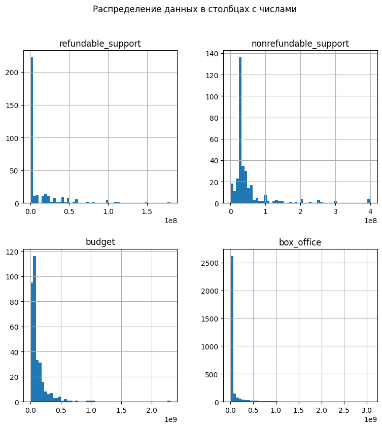

```python
# построим гистограммы по выбранным столбцам
# увеличим количество корзин для большей детализации
# настроим размер графиков с помощью figsize
mkrf[['refundable_support', 'nonrefundable_support', 'budget', 'box_office']].hist(bins=50, figsize=(9,9))

# дадим общее название графикам
plt.suptitle('Распределение данных в столбцах с числами')

# выведем график на экран
plt.show()
```

- В столбцах `refundable_support` и `box_office` виден мощный узкий пик у отметки **0**. Вероятно, в данных есть большое количество нулевых значений или значений, приближенных к минимальному.
- В некоторых столбцах видны отдельные, особенно крупные значения, похожие на выбросы: в `refundable_support` — более **150 000 000 ₽**, в `nonrefundable_support` — около **400 000 000 ₽**, в `budget` — более **2 000 000 000 ₽**.
- На гистограмме по столбцу `nonrefundable_support` заметен длинный узкий хвост, выходящий за отметку в **100 000 000 ₽**.

Каждая гистограмма требует более детального рассмотрения. Для проверки данных на выбросы нужно построить диаграмму размаха для каждого столбца с числами и рассчитать межквартильный размах для наиболее точного результата.

**Выводы:**

1. Два датафрейма `mkrf_movies` и `mkrf_shows` объединили в одну таблицу — `mkrf`.
2. Таблица `mkrf` содержит **16** столбцов и **7 486** строк. Более половины столбцов содержит пропущенные значения.
3. Кроме пропусков, предварительно заметили следующие проблемы в данных: название столбца `puNumber` в camelCase вместо snake_case, некорректный тип данных в столбцах: `puNumber`, `show_start_date`, `ratings`, `refundable_support`, `nonrefundable_support`, `budget`, `box_office`.
4. Вероятно, в столбцах `refundable_support` и `box_office` есть **нулевые** или **близкие к нулю** значения. Возможно наличие выбросов в `refundable_support`, `nonrefundable_support`, `budget` и `box_office`.

## Предобработка данных

### Переименование столбцов

Проверим названия столбцов датафрейма `mkrf`:

```python
# выведем список названий столбцов
mkrf.columns
```

```
Index(['title', 'puNumber', 'show_start_date', 'type', 'film_studio',
       'production_country', 'director', 'producer', 'age_restriction',
       'refundable_support', 'nonrefundable_support', 'budget',
       'financing_source', 'ratings', 'genres', 'box_office'],
      dtype='object')
```

В названии столбца `puNumber` заменим верблюжий регистр на змеиный:

```python
# заменим исходное название с помощью метода rename()
mkrf = mkrf.rename(columns={'puNumber':'pu_number'})

# проверим результат
mkrf.columns
```

```
Index(['title', 'pu_number', 'show_start_date', 'type', 'film_studio',
       'production_country', 'director', 'producer', 'age_restriction',
       'refundable_support', 'nonrefundable_support', 'budget',
       'financing_source', 'ratings', 'genres', 'box_office'],
      dtype='object')
```

### Изменение типов данных

Приведём столбец `show_start_date` со строковым типом данных к типу `datetime`:

```python
# преобразуем строку в datetime с помощью to_datetime()
mkrf['show_start_date'] = pd.to_datetime(mkrf['show_start_date'])

# проверим результат
mkrf['show_start_date'].dtype
```

```
datetime64[ns, UTC]
```

Преобразуем строковый тип данных в столбце `ratings` в `float`:

```python
# заменим тип данных на float с помощью to_numeric()
# используем errors='coerce', чтобы избежать ошибок
mkrf['ratings'] = pd.to_numeric(mkrf['ratings'], errors='coerce')

# проверим результат
mkrf['ratings'].dtype
```

```
dtype('float64')
```

Приведём к целочисленному типу значения в столбцах `refundable_support`, `nonrefundable_support`, `budget`, `box_office`:

```python
# сохраним в переменную столбцы, в которых значения — с нулевой дробной частью
columns_to_astype = ['refundable_support', 'nonrefundable_support', 'budget']

# переведём значения в Int64, так как он может хранить NaN
mkrf[columns_to_astype] = mkrf[columns_to_astype].astype('Int64')

# округлим значения столбца box_office с ненулевой дробной частью и переведём в Int64
mkrf['box_office'] = mkrf['box_office'].round().astype('Int64')

# проверим результат
mkrf.info()
```

```
<class 'pandas.core.frame.DataFrame'>
RangeIndex: 7486 entries, 0 to 7485
Data columns (total 16 columns):
 #   Column                 Non-Null Count  Dtype
---  ------                 --------------  -----
 0   title                  7486 non-null   object
 1   pu_number              7485 non-null   float64
 2   show_start_date        7486 non-null   datetime64[ns, UTC]
 3   type                   7486 non-null   object
 4   film_studio            7468 non-null   object
 5   production_country     7484 non-null   object
 6   director               7477 non-null   object
 7   producer               6918 non-null   object
 8   age_restriction        7486 non-null   object
 9   refundable_support     332 non-null    Int64
 10  nonrefundable_support  332 non-null    Int64
 11  budget                 332 non-null    Int64
 12  financing_source       332 non-null    object
 13  ratings                6490 non-null   float64
 14  genres                 6510 non-null   object
 15  box_office             3158 non-null   Int64
dtypes: Int64(4), datetime64[ns, UTC](1), float64(2), object(9)
memory usage: 965.1+ KB
```

Преобразуем столбец `pu_number` из вещественного в целочисленный тип данных:

```python
# преобразуем тип в Int64, так как он может хранить NaN
mkrf['pu_number'] = mkrf['pu_number'].astype('Int64')

# проверим результат
mkrf['pu_number'].dtype
```

```
Int64Dtype()
```

### Обработка пропущенных значений

Ещё раз ознакомимся с количеством пропущенных значений в каждом столбце датафрейма:

```python
# выведем количество пропусков в каждом столбце по убыванию
mkrf.isna().sum().sort_values(ascending=False)
```

```
refundable_support       7154
nonrefundable_support    7154
budget                   7154
financing_source         7154
box_office               4328
ratings                   996
genres                    976
producer                  568
film_studio                18
director                    9
production_country          2
pu_number                   1
title                       0
show_start_date             0
type                        0
age_restriction             0
dtype: int64
```

Также посмотрим на доли пропусков по столбцам c числами:

```python
# посмотрим на доли пропусков с помощью isna() и mean()
mkrf.isna().mean().sort_values(ascending=False)*100
```

```
refundable_support       95.565055
nonrefundable_support    95.565055
budget                   95.565055
financing_source         95.565055
box_office               57.814587
ratings                  13.304836
genres                   13.037670
producer                  7.587497
film_studio               0.240449
director                  0.120224
production_country        0.026717
pu_number                 0.013358
title                     0.000000
show_start_date           0.000000
type                      0.000000
age_restriction           0.000000
dtype: float64
```

- Больше всего пропусков в столбцах с денежными средствами в рублях: `refundable_support`, `nonrefundable_support` и `budget` — **7154**, а также в `box_office` — **4328**.
- Меньше всего пропущенных значений в столбцах: `director` — **9**, `production_country` — **2**, `pu_number` — **1**.

Заполнение пропусков не требуется в некоторых столблцах, так как не все фильмы в таблице получили государственную поддержку. Например, если заполнить пропуски медианой в столбцах `refundable_support`, `nonrefundable_support`, `budget` это будет означать, что фильмы получили поддержку от государства в определённом размере и привести к некорректным результатам исследования.

Столбцы `genres`, `producer`, `film_studio`, `director` и `production_country`, `financing_source` содержат категориальные переменные. Пропуски в этих столбцах можно заполнить значением "неизвестно" для последующего выявления неявных дублей, более удобного анализа и восприятия:

```python
# выберем нужные столбцы и сохраним их в переменную
category_columns_to_replace = ['genres', 'producer', 'film_studio', 'director', 'production_country', 'financing_source']

# заполним пропуски с помощью fillna()
mkrf[category_columns_to_replace] = mkrf[category_columns_to_replace].fillna('неизвестно')

# проверим результат
mkrf.isna().sum()
```

```
title                       0
pu_number                   1
show_start_date             0
type                        0
film_studio                 0
production_country          0
director                    0
producer                    0
age_restriction             0
refundable_support       7154
nonrefundable_support    7154
budget                   7154
financing_source            0
ratings                   996
genres                      0
box_office               4328
dtype: int64
```

Ознакомимся с информацией о фильме, у которого отсутствует номер прокатного удостоверения в столбце `pu_number`:

```python
# отфильтруем строки с пропусками
mkrf[mkrf['pu_number'].isna()]
```

|  | title | pu_number | show_start_date | type | film_studio | production_country | director | producer | age_restriction | refundable_support | nonrefundable_support | budget | financing_source | ratings | genres | box_office |
| --- | --- | --- | --- | --- | --- | --- | --- | --- | --- | --- | --- | --- | --- | --- | --- | --- |
| 7485 | Курбан-роман. (История с жертвой) | <NA> | 2014-05-15 12:00:00+00:00 | Художественный | ФОНД "ИННОВАЦИЯ" | Россия | С.Юзеев | М.Галицкая | «12+» - для детей старше 12 лет | <NA> | <NA> | <NA> | неизвестно | NaN | неизвестно | <NA> |

Данные об этом фильме выгрузились корректно, так как на [портале открытых данных Министерства культуры](https://opendata.mkrf.ru/) в разделе ["Реестр прокатных удостоверений фильмов"](https://opendata.mkrf.ru/opendata/7705851331-register_movies) действительно отсутсвует информация о номере прокатного удостоверения для фильма "Курбан-роман. (История с жертвой)" от 2014.05.15.

Согласно информации на портале, этот фильм получил номер прокатного удостоверения позже — 2014.09.02. В названии фильма появилась точка - "Курбан-роман. (История с жертвой).".

Выведем информацию о фильме в датафрейме `mkrf`:

```python
# отфильтруем строки датафрейма
mkrf[mkrf['title'] == 'Курбан-роман. (История с жертвой).']
```

|  | title | pu_number | show_start_date | type | film_studio | production_country | director | producer | age_restriction | refundable_support | nonrefundable_support | budget | financing_source | ratings | genres | box_office |
| --- | --- | --- | --- | --- | --- | --- | --- | --- | --- | --- | --- | --- | --- | --- | --- | --- |
| 877 | Курбан-роман. (История с жертвой). | 111009614 | 2014-09-02 12:00:00+00:00 | Художественный | ФОНД "ИННОВАЦИЯ" | Россия | С.Юзеев | М.Галицкая | «12+» - для детей старше 12 лет | <NA> | <NA> | <NA> | неизвестно | NaN | неизвестно | 0 |

Номер удостоверения фильма — **111009614**, а премьера состоялась 2014.09.02. Сомнения вызывает значение **0** в столбце о сборах в рублях — `box_office`. Нулевое значение говорит о том, что фильм не вышел в прокат или была допущена ошибка при внесении данных в таблицу. Мы обработаем аномалии в этом столбце позже.

Следует удалить строку с пропущенным значением в столбце `pu_number` из датафрейма, так как данные об этом фильме трудно назвать информативными из-за большого отсутствия пропусков в разных столбцах.

```python
# удалим строку со значением NA и сохраним результат
mkrf = mkrf[mkrf['pu_number'].notna()]

# проверим результат
mkrf.isna().sum()
```

```
title                       0
pu_number                   0
show_start_date             0
type                        0
film_studio                 0
production_country          0
director                    0
producer                    0
age_restriction             0
refundable_support       7153
nonrefundable_support    7153
budget                   7153
financing_source            0
ratings                   995
genres                      0
box_office               4327
dtype: int64
```

### Обработка дубликатов

Проверим данные на наличие явных дубликатов:

```python
# проверим таблицу на дубликаты с помощью duplicated()
mkrf.duplicated().sum()
```

```
0
```

В таблице отсутствуют явные дубликаты.

После преобразования к числовому типу данных, проверим столбец `'pu_number'` с номерами прокатного удостоверения на неявные дубликаты:

```python
# выведем список уникальных значений с помощью unique()
print(sorted(mkrf['pu_number'].unique()))
```

```
[1811096, 111000110, 111000111, 111000112, 111000113, 111000114, 111000115, 111000116, 111000117, 111000118, 111000119, 111000210, 111000211, 111000212, 111000213, 111000214, 111000215, 111000216, 111000217, 111000218, 111000219, 111000310, 111000311, 111000312, 111000313, 111000314, 111000315, 1110…
```

Значения в столбце выглядят достаточно упорядоченно. Неявные дубликаты отсутствуют.

### Изучение столбцов с категориальными переменными: обработка неявных дубликатов

- Изучим уникальные значения столбцов с категориальными переменными: `title`, `type`, `film_studio`, `production_country`, `director`, `producer`, `age_restriction`, `financing_source`, `genres`.
- Обработаем неявные дубликаты в столбцах.

#### Изучение столбца 'title'

Проверим список уникальных значений в столбце `title`:

```python
# выведем список уникальных значений
sorted(mkrf['title'].unique())
```

```
[' Я ПРЕПОД',
 '"SOS" над тайгой',
 '"V" значит вендетта',
 '"АРТиШОК" анимационный альманах авторских фильмов',
 '"Бежин луг" Сергея Эйзенштейна',
 '"Державная" Размышления 100 лет спустя',
 '"Зеленое яблоко" анимационный альманах выпуск № 7',
 '"Машины песенки". Серия "Опять Новый Год!"',
 '"Море"',
 '"Сезон дождей", "Диета Матроскина", "Шарик хочет телефон" из анимационного сериала "Простоквашино"',
 '"Старый" Новый год',
 '"Уорнер Бразерс Пикчерз" и "Леджендари Пикчерз": Тихоокеанский рубеж',
 '"Фееринки". Серия "Фантик спешит на помощь"',
 '"Хороший день", "Бог из машины/Deus EX", "Голод", "Психотроника", "Темная ночь"',
 '"Чудовище из Простоквашино", "Ген героя", "Ненастоящий детектив", "Мама и Тама", "Как бы не стало зимы" из анимационного сериала "Простоквашино"',
 '#ВСЁ_ИСПРАВИТЬ!?!',
 '#Москва-Руаян',
 '#ЯВОЛОНТЕР Истории неравнодушных',
 '(Не)жданный принц',
 '(Не)идеальный мужчина',
 '... в стиле JAZZ',
 '... и я там был',
 '... имени Сергея Герасимова',
 '007 Координаты Скайфолл',
 '007: Спектр',
 '1+1',
 '1+1. Нарушая правила',
 '1+1: Голливудская история',
 '10 000 км.: Любовь на расстоянии',
 '10 000 лет до н.э.',
 '10 лет спустя',
 '10 лет спустя.',
 '10 мгновений судьбы',
 '100 вещей и ничего лишнего',
 '100 лет Чувашской автономии',
 '100 лет дизайна',
 '100 миллионов евро',
 '1001 рецепт влюбленного кулинара',
 '11 минут',
 '11-11-11',
```

[output cut: 946 more lines]

```
 'Властелин разметки',
 'Властелин танца 3D',
 'Власть',
 'Власть убеждений',
 'Влечение .',
 'Влюбленные_',
 'Влюбленный скорпион /По роману Карлоса Бардема/',
 'Вне Игры (серии 1-12)',
 'Вне времени (2014)',
 'Вне поля зрения /По роману Элмора Леонарда/',
 'Вне/себя',
 'Внеклассные занятия в 3D (Монстры из бездны; Язык насекомых; Как устроена клетка; Путешествие к солнцу)',
 'Внимание, черепаха!',
 'Внутри Льюина Дэвиса',
 ...]
```

- Чаще всего одни и те же названия фильмов дублируются с разными знаками пунктуации. Например, `'10 лет спустя'` и `'10 лет спустя.'`;
- Встречаются наименования в верхнем и нижнем регистре, что может стать причиной появления неявных дубликатов в столбце: `'#ЯВОЛОНТЕР Истории неравнодушных'`, или `' Я ПРЕПОД'`;
- Пробелы в начале и в конце строк.

Дубликаты могли возникнуть ввиду человеческого фактора. Например, при внесении данных в таблицу вручную.

Обработаем неявные дубликаты в столбце `title`:

```python
# приведём все значения к нижнему регистру с помощью str.lower()
mkrf['title'] = mkrf['title'].str.lower()

# проверим результат
sorted(mkrf['title'].unique())
```

```
[' я препод',
 '"sos" над тайгой',
 '"v" значит вендетта',
 '"артишок" анимационный альманах авторских фильмов',
 '"бежин луг" сергея эйзенштейна',
 '"державная" размышления 100 лет спустя',
 '"зеленое яблоко" анимационный альманах выпуск № 7',
 '"машины песенки". серия "опять новый год!"',
 '"море"',
 '"сезон дождей", "диета матроскина", "шарик хочет телефон" из анимационного сериала "простоквашино"',
 '"старый" новый год',
 '"уорнер бразерс пикчерз" и "леджендари пикчерз": тихоокеанский рубеж',
 '"фееринки". серия "фантик спешит на помощь"',
 '"хороший день", "бог из машины/deus ex", "голод", "психотроника", "темная ночь"',
 '"чудовище из простоквашино", "ген героя", "ненастоящий детектив", "мама и тама", "как бы не стало зимы" из анимационного сериала "простоквашино"',
 '#всё_исправить!?!',
 '#москва-руаян',
 '#яволонтер истории неравнодушных',
 '(не)жданный принц',
 '(не)идеальный мужчина',
 '... в стиле jazz',
 '... и я там был',
 '... имени сергея герасимова',
 '007 координаты скайфолл',
 '007: спектр',
 '1+1',
 '1+1. нарушая правила',
 '1+1: голливудская история',
 '10 000 км.: любовь на расстоянии',
 '10 000 лет до н.э.',
 '10 лет спустя',
 '10 лет спустя.',
 '10 мгновений судьбы',
 '100 вещей и ничего лишнего',
 '100 лет дизайна',
 '100 лет чувашской автономии',
 '100 миллионов евро',
 '1001 рецепт влюбленного кулинара',
 '11 минут',
 '11-11-11',
```

[output cut: 946 more lines]

```
 'воды слонам! /по произведению сары груэн/',
 'водяная',
 'вождь разнокожих',
 'возврата нет.',
 'возвращение буратино',
 'возвращение буратино 3d',
 'возвращение в "а"',
 'возвращение в бургундию',
 'возвращение в простоквашино. часть 2 из анимационного сериала "простоквашино"',
 'возвращение василия бортникова',
 'возвращение героя',
 'возвращение саввы',
 'возвращение супермена',
 'воздушный маршал',
 ...]
```

```python
# напишем функцию для замены подстрок элементов в столбце с помощью str.replace() и regex=False
def names_to_str_replace(column, values):
    for old_name, new_name in values:
        mkrf[column] = mkrf[column].str.replace(old_name, new_name, regex=False)

# вызовем функцию
names_to_str_replace('title', [
    (' .','.'),
    ('/.','.'),
    (' _',''),
    ('._', '.'),
    ('_', '.'),
    (').', ')'),
    (' -', '')
])

# заменим отдельный элемент столбца с помощью replace()
mkrf['title'] = mkrf['title'].replace(
    {
        'астрал. глава 2':'астрал. глава вторая',
    }
)

# уберём многоточия и решётки в начале названий
# уберём точки, слэши и дефисы в конце названий
# уберём пробелы в начале и в конце строк
mkrf['title'] = mkrf['title'].str.lstrip('...#').str.rstrip('./-').str.strip()
```

```python
# проверим результат, применив сортировку по возрастанию
sorted(mkrf['title'].unique())
```

```
['"sos" над тайгой',
 '"v" значит вендетта',
 '"артишок" анимационный альманах авторских фильмов',
 '"бежин луг" сергея эйзенштейна',
 '"державная" размышления 100 лет спустя',
 '"зеленое яблоко" анимационный альманах выпуск № 7',
 '"машины песенки". серия "опять новый год!"',
 '"море"',
 '"сезон дождей", "диета матроскина", "шарик хочет телефон" из анимационного сериала "простоквашино"',
 '"старый" новый год',
 '"уорнер бразерс пикчерз" и "леджендари пикчерз": тихоокеанский рубеж',
 '"фееринки". серия "фантик спешит на помощь"',
 '"хороший день", "бог из машины/deus ex", "голод", "психотроника", "темная ночь"',
 '"чудовище из простоквашино", "ген героя", "ненастоящий детектив", "мама и тама", "как бы не стало зимы" из анимационного сериала "простоквашино"',
 '(не)жданный принц',
 '(не)идеальный мужчина',
 '007 координаты скайфолл',
 '007: спектр',
 '1+1',
 '1+1. нарушая правила',
 '1+1: голливудская история',
 '10 000 км.: любовь на расстоянии',
 '10 000 лет до н.э',
 '10 лет спустя',
 '10 мгновений судьбы',
 '100 вещей и ничего лишнего',
 '100 лет дизайна',
 '100 лет чувашской автономии',
 '100 миллионов евро',
 '1001 рецепт влюбленного кулинара',
 '11 минут',
 '11-11-11',
 '118 секунд, до... и после',
 '12 лет рабства',
 '12 мелодий любви',
 '12 месяцев',
 '12 месяцев. новая сказка',
 '120/80',
 '127 часов',
 '128 ударов сердца в минуту',
```

[output cut: 946 more lines]

```
 'воин.com',
 'воины света',
 'вой банши',
 'война',
 'война (2016)',
 'война анны',
 'война богов: бессмертные 3d',
 'война драконов',
 'война миров z',
 'война полов',
 'война против всех',
 'война токов',
 'вокс люкс',
 'волк и семеро козлят',
 ...]
```

#### Изучение столбца 'type'

Проверим список уникальных значений в столбце `type`:

```python
# выведем список уникальных значений
mkrf['type'].unique()
```

```
array(['Художественный', ' Художественный', 'Научно-популярный',
       'Анимационный', 'Документальный', ' Анимационный', 'Прочие',
       'Музыкально-развлекательный'], dtype=object)
```

В столбце с типом фильма обнаружили **2** неявных дубликата с лишними пробелами. Они могли возникнуть по техническим причинам, при загрузке или выгрузке данных.

Обработаем дубликаты в столбце:

```python
# обработаем дубликаты с помощью replace()
mkrf['type'] = mkrf['type'].replace({' Художественный':'Художественный', ' Анимационный':'Анимационный'})

# проверим результат
mkrf['type'].unique()
```

```
array(['Художественный', 'Научно-популярный', 'Анимационный',
       'Документальный', 'Прочие', 'Музыкально-развлекательный'],
      dtype=object)
```

#### Изучение столбца 'film_studio'

Проверим список уникальных значений в столбце `film_studio`:

```python
# выведем список уникальных значений
sorted(mkrf['film_studio'].unique())
```

```
[' АНО "Кинофорум"',
 ' Ауматик Интертейнмент, Блюмхаус Продакшнз и др.',
 ' ЗАО "Кинокомпания ФаворитФильм" по заказу ООО "ФАВОРИТ МЕДИА"',
 ' Константин Фильм, А Эр Ди Дегето Фильм, Дюне Филис, Икури Филмз, Медуза Фильм, У Эф А Интернэшнл Филм энд Ти Ви Продуцион, Юниверсум Филм ',
 ' ООО "АВАТАРА"',
 ' ООО "КОСТАФИЛЬМ"',
 ' ООО "КиноФирма"',
 ' ООО "Кинокомпания "Студия ПРЕССИНГ"',
 ' ООО "Магнум-фильм"',
 ' ООО "Продюсерская фирма Игоря Толстунова"',
 ' ООО "Студия "Рой"',
 ' ООО "Студия 25", ООО "Медиа Арт Студио", ООО "Продюсерский центр "Синема Продакшн" ',
 ' ООО "Студия МЕТРАФИЛЬМС", Компания "TASSE film", Компания "SIRENA film"',
 ' ООО "ТаББаК"',
 ' ООО "ТаББаК", ООО "Анимационная студия "Москва"',
 ' ООО "ТаББаК", ООО "Весёлая Компания"',
 ' ООО "Форс Медиа"',
 ' ООО "Хардкор", ООО "Патриот продакшнс"',
 ' ООО "Энджой мувиз"',
 ' ООО "Энджой мувиз", ООО "Эмоушен Пикчерз", ООО "РЕНОВАЦИО интертейнмент"',
 ' ООО Продюсерский центр "Фёдор Добронравов"',
 ' Юниверсал Пикчерз',
 '"Дино де Лаурентиис" (Италия) при участии Киностудии "Мосфильм"',
 '"Союздетфильм", "Мосфильм", "Москинокомбинат"',
 '"Студия "Птица Феникс" Татьяны Новиковой',
 '"Эскиз и Каргин Студио"',
 '02 Филмз, Ромбэс Медиа',
 '100 Барес, 369 Продюксьонес, Антен 3 Фильм, Катманду Брендид Интертейнмент, Плюраль - Джемпса, Прана Анимейшн Студиос, Телевизион Федераль',
 '100 Барес, Институто Националь де Сине и Артс Аудивизуалес, Институто де ла Синематографиа и де ла Артс Аудивизуалес, Министеро де Култура, Телевизион Федераль, Торнасол Фильм   ',
 '100 Барс, Канал + Испания, Хаддок Фильм, Институто Националь Сине Арте Аудивизуаль, Институто де Кредито Офисиаль, Телевидение Испании, Федеральное Телевидение, Торнасол Филмз ',
 '1000 Айз, Брон Криэйтив Студиос, Нью Лайн Синема',
 '1212 Интертейнмент, Си Би Эс Филмз, Ди Ди Уай, Интертейнмент Уан, Шон Дэниэл Компани',
 '1492 Пиксерз, Коламбиа Пикчерз, Хэппи Медисон Пикчерз',
 '1492 Пикчерз, Фокс 2000 Пикчерз, Импринт Интертейнмент, ХХ век Фокс',
 '16:14 Интертейнмент, Алкон Интертейнмент, Коламбиа Пикчерз, Скотт Фри Продакшнз, Тандерберд Интертейнмент, Торридон Филмз, Уорнер Бразерс',
 '1821 Пикчерз',
 '1984 Прайвет Дефенс Контракторс, Кросс Крик Пикчерз, Да Винчи Медиа Венчурс, Дубль Фьючер Филмз, Эксклюзив Медиа Групп, Фри Стейт Пикчерз, Джерси Филмз, Трэвелинг Пикчерз Шоу Компани',
 '1984 Приват Дефенс Контракторс, Менделей Вижн, Студио Бабелсберг, Вертиго Интертейнмент',
 '2 ДиЭс Продакшнз',
 '2.0 Интертейнмент, Браунстоун Продакшнз, Коламбия Пикчерс, Сони Пикчерс Интертейнмент',
```

[output cut: 946 more lines]

```
 'ГТПО "Мосфильм", "КСТ"',
 'ГУП РБ Киностудия "Башкортостан"',
 'ГУП Республики Башкортостан Киностудия "Башкортостан"',
 'Габриэль Польски Продакшнс',
 'Гага, Фуджи ТиВи Мувис, Аой Промоушн',
 'Гайд Парк Интертейнмент, Каламбиа Пикчерз, Имеджинэйшн Абу Даби, Мэрвил Кнайтс',
 'Гайи Фильм',
 'Гайнакс',
 'Гайссендёрфер Филм - унд Фернзеепродуцион, Лайблингсфилм Гмбх, Мем-фильм Гмбх, Теле-Мюнхен ',
 'Галатэ Фильм, Аутсайд Фильм, Фильм Африка Ворлдвайд, Эм Эс Фильм, Студио Каналь',
 'Галкина Вероника Львовна',
 'Галлен Филмз, Комплайзен Филм, О Сом и э Фуриа, Радиотелевизао Португаеса, Шеллак Студио, Зе Де Эф/Арте',
 'Галлопинг Хорс Калче энд Медиа, Чайна Филм Групп, Лион Рок Продакшнз, Йозо Пикчерз, Шейанг Хуас Филм энд Ти Ви',
 'Галп Сплэш Продакшнз, Вэнишин Энгл',
 ...]
```

В этом случае, неявные дубликаты могли возникнуть из-за человеческого фактора при передаче лексических единиц с английского языка на русский. Одни и те же слова передаются двумя способами: транскрипцией и транслитерацией.

Например: `Анимейшнз` и `Анимейшнс` (на англ. animations), `Ток` и `Талк` (на англ. talk).

Также встречаются:

- Полное название и его аббревиатура: `Государственная национальная компания` и `ГНК`;
- Написание одних и тех же названий в верхнем и нижнем регистре: `СТЕЛЛА` и `Стелла`;
- Использование разных знаков препинания: `'АО "ТНТ-Телесеть", ООО "Продюсерская компания "Среда", ООО "Ника ТВ"',` и `'АО "ТНТ-Телесеть", ООО Продюсерская компания "Среда", ООО "Ника ТВ"'`;
- Пробелы в начале строк.

Обработаем дубликаты в столбце:

```python
# приведём все значения к нижнему регистру c помощью метода str.lower()
mkrf['film_studio'] = mkrf['film_studio'].str.lower()

# проверим результат
sorted(mkrf['film_studio'].unique())
```

```
[' ано "кинофорум"',
 ' ауматик интертейнмент, блюмхаус продакшнз и др.',
 ' зао "кинокомпания фаворитфильм" по заказу ооо "фаворит медиа"',
 ' константин фильм, а эр ди дегето фильм, дюне филис, икури филмз, медуза фильм, у эф а интернэшнл филм энд ти ви продуцион, юниверсум филм ',
 ' ооо "аватара"',
 ' ооо "кинокомпания "студия прессинг"',
 ' ооо "кинофирма"',
 ' ооо "костафильм"',
 ' ооо "магнум-фильм"',
 ' ооо "продюсерская фирма игоря толстунова"',
 ' ооо "студия "рой"',
 ' ооо "студия 25", ооо "медиа арт студио", ооо "продюсерский центр "синема продакшн" ',
 ' ооо "студия метрафильмс", компания "tasse film", компания "sirena film"',
 ' ооо "таббак"',
 ' ооо "таббак", ооо "анимационная студия "москва"',
 ' ооо "таббак", ооо "весёлая компания"',
 ' ооо "форс медиа"',
 ' ооо "хардкор", ооо "патриот продакшнс"',
 ' ооо "энджой мувиз"',
 ' ооо "энджой мувиз", ооо "эмоушен пикчерз", ооо "реновацио интертейнмент"',
 ' ооо продюсерский центр "фёдор добронравов"',
 ' юниверсал пикчерз',
 '"дино де лаурентиис" (италия) при участии киностудии "мосфильм"',
 '"союздетфильм", "мосфильм", "москинокомбинат"',
 '"студия "птица феникс" татьяны новиковой',
 '"эскиз и каргин студио"',
 '02 филмз, ромбэс медиа',
 '100 барес, 369 продюксьонес, антен 3 фильм, катманду брендид интертейнмент, плюраль - джемпса, прана анимейшн студиос, телевизион федераль',
 '100 барес, институто националь де сине и артс аудивизуалес, институто де ла синематографиа и де ла артс аудивизуалес, министеро де култура, телевизион федераль, торнасол фильм   ',
 '100 барс, канал + испания, хаддок фильм, институто националь сине арте аудивизуаль, институто де кредито офисиаль, телевидение испании, федеральное телевидение, торнасол филмз ',
 '1000 айз, брон криэйтив студиос, нью лайн синема',
 '1212 интертейнмент, си би эс филмз, ди ди уай, интертейнмент уан, шон дэниэл компани',
 '1492 пиксерз, коламбиа пикчерз, хэппи медисон пикчерз',
 '1492 пикчерз, фокс 2000 пикчерз, импринт интертейнмент, хх век фокс',
 '16:14 интертейнмент, алкон интертейнмент, коламбиа пикчерз, скотт фри продакшнз, тандерберд интертейнмент, торридон филмз, уорнер бразерс',
 '1821 пикчерз',
 '1984 прайвет дефенс контракторс, кросс крик пикчерз, да винчи медиа венчурс, дубль фьючер филмз, эксклюзив медиа групп, фри стейт пикчерз, джерси филмз, трэвелинг пикчерз шоу компани',
 '1984 приват дефенс контракторс, менделей вижн, студио бабелсберг, вертиго интертейнмент',
 '2 диэс продакшнз',
 '2.0 интертейнмент, браунстоун продакшнз, коламбия пикчерс, сони пикчерс интертейнмент',
```

[output cut: 946 more lines]

```
 'галатэ фильм, аутсайд фильм, фильм африка ворлдвайд, эм эс фильм, студио каналь',
 'галкина вероника львовна',
 'галлен филмз, комплайзен филм, о сом и э фуриа, радиотелевизао португаеса, шеллак студио, зе де эф/арте',
 'галлопинг хорс калче энд медиа, чайна филм групп, лион рок продакшнз, йозо пикчерз, шейанг хуас филм энд ти ви',
 'галп сплэш продакшнз, вэнишин энгл',
 'гамбит пикчерз, электрик шеперд продакшнз, медиа райт кэпитал, юниверсал пикчерз',
 'ганни интертейнмент',
 'ганнибал пикчерз, ю эс эс индианаполис продакшн',
 'ганхил, сайборн, ивес агеманс',
 'гапиенко заур александрович',
 'гапон юрий витальевич',
 'гари санчез продакшнс',
 'гарифуллин рамиль рамзиевич',
 'гармата филм продакшн',
 ...]
```

```python
# вызовем функцию для замены подстрок
names_to_str_replace('film_studio', [
    ('лапс','лэпс'),
    ('мс','мз'),
    ('пикчерс','пикчерз'),
    ('нтэр','нтер'),
    ('эй','ей'),
    ('эшн','ешн'),
    ('иксер', 'икчер'),
    ('втом', 'утом'),
    ('ллевн', 'левен'),
    ('ейв', 'эйв'),
    ('орел', 'орёл'),
    ('групп', 'груп'),
    ('эйшн', 'ейшн'),
    ('азис','айзис'),
    ('айм', 'айэм'),
    ('оад', 'оард'),
    ('ксэль', 'ксель'),
    ('филм', 'фильм'),
    ('иос', 'иоз'),
    ('зоэтроп', 'зоэтроуп'),
    ('зоетроуп', 'зоэтроуп'),
    ('ьюс', 'ьюз'),
    ('би-би-си', 'би би си'),
    ('бибиси', 'би би си'),
    ('талк', 'ток'),
    ('бэн', 'бен'),
    ('бигер','биггер'),
    ('бот', 'боат'),
    ('эдж', 'эйдж'),
    ('шнс', 'шнз'),
    ('ауто', 'авто'),
    ('аума', 'автома'),
    ('айто', 'авто'),
    ('ирзк', 'ирск'),
    ('алианз', 'алльянз'),
    ('монзт', 'монст'),
    ('автономная некоммерческая организация','ано'),
    ('государственная национальная компания', 'гнк'),
    ('анимейшнзз', 'анимейшнз'),
    ('агат фильм / си', 'агат фильм и си'),
    ('ареми продюксьон', 'артеми продюксьон'),
    ('а энд е инди фильмз', 'а энд и индефильмз'),
    ('барс', 'барес'),
    ('акрс энд а мьюл фильмворкс', 'ейкерс энд мьюл фильмворкс'),
    ('87элевен', '87 элевен'),
    ('алианс', 'алльянс'),
    ('альянс', 'алльянс'),
    ('артэ франс синема', 'артэ франсе синема'),
    ('ле пакт', 'лё пакт'),
    ('раи чинема', 'рай синема'),
    ('ейнмент', 'еймент'),
    ('бавариа', 'бавария'),
    ('багдасариан', 'багдасарян'),
    ('бакаро', 'бакару'),
    ('вижуал', 'визуал'),
    ('толк', 'ток'),
    ('блиндинг', 'блайндинг'),
    ('блайдинг', 'блайндинг'),
    ('блюмхаус', 'блюмхауз'),
    ('интертеймент ван', 'интертеймент уан'),
    ('беар', 'беа'),
    ('биар', 'беа'),
    ('бир', 'беа'),
    ('роард', 'роуд'),
    ('брукин', 'броукен'),
    ('вондерволд', 'вондерворлд'),
    ('ворлдвье', 'ворлдвью'),
    ('ворлдвьё', 'ворлдвью'),
    ('им.с.а.герасимова', 'имени с.а. герасимова'),
    ('им. с.а.герасимова', 'имени с.а. герасимова'),
    ('"продюсерская компания "среда"', 'продюсерская компания "среда"'),
    ('им. м.горького', 'им. м. горького'),
    ('им.м.горького', 'им. м. горького'),
    ('сэкл', 'сёкл'),
    ('2.4.7.фильм', '2.4.7. фильм'),
    ('аардам', 'аардман'),
    ('автономное учреждение республики саха (якутия) гнк "сахафильм"', 'ау рс(я) гнк "сахафильм"'),
    ('ау республики саха (якутия) гнк "сахафильм"', 'ау рс(я) гнк "сахафильм"'),
    ('автономное учреждение республики саха (якутия) "гнк "сахафильм"', 'ау рс(я) гнк "сахафильм"'),
    ('приват', 'прайвет')
])

#удалим пробелы в начале и в конце строк с помощью str.strip()
mkrf['film_studio'] = mkrf['film_studio'].str.strip()
```

```python
# проверим результат
sorted(mkrf['film_studio'].unique())
```

```
['"дино де лаурентиис" (италия) при участии киностудии "мосфильм"',
 '"союздетфильм", "мосфильм", "москинокомбинат"',
 '"студия "птица феникс" татьяны новиковой',
 '"эскиз и каргин студио"',
 '02 фильмз, ромбэс медиа',
 '100 барес, 369 продюксьонес, антен 3 фильм, катманду брендид интертеймент, плюраль - джемпса, прана анимейшн студиоз, телевизион федераль',
 '100 барес, институто националь де сине и артс аудивизуалес, институто де ла синематографиа и де ла артс аудивизуалес, министеро де култура, телевизион федераль, торнасол фильм',
 '100 барес, канал + испания, хаддок фильм, институто националь сине арте аудивизуаль, институто де кредито офисиаль, телевидение испании, федеральное телевидение, торнасол фильмз',
 '1000 айз, брон криейтив студиоз, нью лайн синема',
 '1212 интертеймент, си би эс фильмз, ди ди уай, интертеймент уан, шон дэниэл компани',
 '1492 пикчерз, коламбиа пикчерз, хэппи медисон пикчерз',
 '1492 пикчерз, фокс 2000 пикчерз, импринт интертеймент, хх век фокс',
 '16:14 интертеймент, алкон интертеймент, коламбиа пикчерз, скотт фри продакшнз, тандерберд интертеймент, торридон фильмз, уорнер бразерс',
 '1821 пикчерз',
 '1984 прайвет дефенс контракторс, кросс крик пикчерз, да винчи медиа венчурс, дубль фьючер фильмз, эксклюзив медиа груп, фри стейт пикчерз, джерси фильмз, трэвелинг пикчерз шоу компани',
 '1984 прайвет дефенс контракторс, менделей вижн, студио бабелсберг, вертиго интертеймент',
 '2 диэс продакшнз',
 '2.0 интертеймент, браунстоун продакшнз, коламбия пикчерз, сони пикчерз интертеймент',
 '2.0 интертеймент, энимал лоджик интертеймент, энимал лоджик, коламбиа пикчерз, олив бридж интертеймент, скрин австралиа, сони пикчерз анимейшн, сони пикчерз интертеймент',
 '2.4.7. фильм, марс фильм, панаш продюксьон, компани синематографик, радио телевизьон бельж франкофон, оранж синема, сине +, банк посталь имаж 8, софисинема 11, фильм дистрибусьон, индефильм 3',
 '2.4.7. фильм, франс 2 синема, студио канал, сине, банк посталь имаж 4, палатен этуаль 8, панаш продюксьон, компани синематографик эуропенн, канал +',
 '20 сенчюри фокс де архентина, чемо, ейчби фильмз, айэнсиейей',
 '2003 продюксьон, уорнер бразерс, тапиока продюксьон, тф1 фильм продюксьон, канал +, центр националь де ля синематографи',
 '21 лэпс интертеймент, медиа мэйджик интертеймент, хх век фокс',
 '21 лэпс интертеймент, фильмнейшн интертеймент, лава беа фильмз',
 '21 лэпс интертеймент, хх век фокс',
 '224 интертеймент, интринсик вэльюи фильмз',
 '24 каре фильм',
 '24 май продюксьон, франс 2 синема',
 '26 фильмз, канзамэн продакшнз, плейтон продакшнз',
 '2929 продакшнз, индастри интертеймент',
 '2929 продакшнз, коста фильмз, паркес/макдоналд продакшнз',
 '2929 продакшнз, чокстоун пикчерз, ник векслер продакшнз, студиоканаль',
 '2929 продакшнз,эндинет фильмз, экстеншион 765',
 '2дэ3дэ анимейшн, комета фильм, ирис продакшнз, валкинг зе дог',
 '2с фильм',
 '3 алити диджитал',
 '3 артс интертеймент, дабл фичер фильмз, пипай фильмз',
 '3 артс интертеймент, джоли пас, леджендари пикчерз, юниверсал пикчерз',
 '3 артс интертеймент, крейзи хорз эффектс,флэшпойнт интертеймент, фокс 2000 пикчерз',
```

[output cut: 946 more lines]

```
 'глобал генезис груп',
 'глобал генезис груп, сагатон',
 'глобал роуд интертеймент, ай эм глобал, шубокс фильмз, старлингз интертеймент',
 'глобал роуд интертеймент, лейкшор интертепйнмент, фантом фор фильмз',
 'глобал роуд интертеймент, отоматик',
 'глори энд дрим студиоз, индастри вокс пикчерз',
 'глосс',
 'говард холл продакшнз, айэмакс корпорейшн, уорнер бразерс',
 'говард холл продакшнз, айэмакс корпорейшн, уорнер бразерс, локхид мартин, наса',
 'голд кикле фильмз',
 'голд серкл, эр джи би медиа',
 'голд спринг пикчерз, дв студиоз, монтесито пикчер компани, парамаунт пикчерз, райт оф вей фильмз',
 'голд сёкл фильмз, дэд кроу продакшнз, чамбара пикчерз, форс кайнд продакшнз',
 'голд сёкл фильмз, куикфаэ фильмз',
 ...]
```

#### Изучение столбца 'director'

Проверим список уникальных значений столбца `director`:

```python
# выведем список уникальных значений
sorted(mkrf['director'].unique())
```

```
[' Йохан Нийенхейс',
 ' Н.Орлов, Р.Быков',
 ' Р.Асхаев',
 ' Т.Саакян',
 ' Ф.Бондарчук',
 'Ёлкин Туйчиев',
 'Ён Сан-хо',
 'А Андрющенко',
 'А. Калюжный',
 'А. Кутерье',
 'А.А.Эшпай',
 'А.Аббасов',
 'А.Абидова (псевдоним Аниса Сабири)',
 'А.Аболс',
 'А.Агаджанян',
 'А.Адилханян',
 'А.Адраникян',
 'А.Аксененко',
 'А.Аксененко, Э.Никогосян, Д.Дюжев, А.Вакулов (А.Кульбицкий)',
 'А.Алов, В.Наумов',
 'А.Аманшаев, Г.Шенгелия',
 'А.Амбросьев',
 'А.Амиров',
 'А.Ананикян, В.Рейнгеверц',
 'А.Андрианов',
 'А.Андризани, А.Бардани, В.Карнелутти, Ф.Коста,  Г.С.Нардис, В.Пальмьери, В.Чеа, А.Юлиано ',
 'А.Анненский',
 'А.Аравин',
 'А.Аравин, А.Прошкин',
 'А.Арпеньтеньер, А.Бариларо, М.Бланчес, Р.Валлей, Л.Гранд, Ф.Дион, А.Жасина, Э.Коэтс,  Лу Хаму-Лхад, П.Осборн, Т.Ушев',
 'А.Артамонова',
 'А.Арутюнов',
 'А.Арутюнян, А.Коршунов',
 'А.Атанесян',
 'А.Бадягина',
 'А.Бажанов',
 'А.Балабанов',
 'А.Балахонов',
 'А.Бальчев',
 'А.Баранов',
```

[output cut: 946 more lines]

```
 'Вольфганг Лауэнштайн, Кристоф Лауэнштайн',
 'Вольфганг Лауэнштайн, Кристоф Лауэнштайн, Шон МакКормак',
 'Вольфганг Петерсен',
 'Вольфганг Петерсон',
 'Вон Стайн',
 'Вонг Кар Вай',
 'Вонг Чинг По',
 'Вонг Юнфей',
 'Вуди Аллен',
 'Вэй Кеунг Лау, Эндрю Лу',
 'Вэйшали Синха',
 'Г.Александров',
 'Г.Бардин',
 'Г.Бежанов',
 ...]
```

В столбце можно заметить:

- Неявные дубликаты имён режиссёров, которые возникли из-за наличия псевдонимов в таблице. Например: `'А.Михалков (псевдоним А.Кончаловский)'`, `'А.Кончаловский'`, `'А.Михалков-Кончаловский'` и `'А.Михалков'`;
- Неявные дубликаты в результате разных способов перевода одного и того же имени на русский язык: `'Вольфганг Петерсон'` и `'Вольфганг Петерсен'`.

Также видны строки с пробелами в начале и лишними пробелами после точки, отсутствие точки.

Обработаем дубликаты:

```python
# вызовем функцию для замены подстрок
names_to_str_replace('director', [
    ('. ','.')
])

# проверим результат
sorted(mkrf['director'].unique())
```

```
[' Йохан Нийенхейс',
 ' Н.Орлов, Р.Быков',
 ' Р.Асхаев',
 ' Т.Саакян',
 ' Ф.Бондарчук',
 'Ёлкин Туйчиев',
 'Ён Сан-хо',
 'А Андрющенко',
 'А.А.Эшпай',
 'А.Аббасов',
 'А.Абидова (псевдоним Аниса Сабири)',
 'А.Аболс',
 'А.Агаджанян',
 'А.Адилханян',
 'А.Адраникян',
 'А.Аксененко',
 'А.Аксененко, Э.Никогосян, Д.Дюжев, А.Вакулов (А.Кульбицкий)',
 'А.Алов, В.Наумов',
 'А.Аманшаев, Г.Шенгелия',
 'А.Амбросьев',
 'А.Амиров',
 'А.Ананикян, В.Рейнгеверц',
 'А.Андрианов',
 'А.Андризани, А.Бардани, В.Карнелутти, Ф.Коста,  Г.С.Нардис, В.Пальмьери, В.Чеа, А.Юлиано ',
 'А.Анненский',
 'А.Аравин',
 'А.Аравин, А.Прошкин',
 'А.Арпеньтеньер, А.Бариларо, М.Бланчес, Р.Валлей, Л.Гранд, Ф.Дион, А.Жасина, Э.Коэтс,  Лу Хаму-Лхад, П.Осборн, Т.Ушев',
 'А.Артамонова',
 'А.Арутюнов',
 'А.Арутюнян, А.Коршунов',
 'А.Атанесян',
 'А.Бадягина',
 'А.Бажанов',
 'А.Балабанов',
 'А.Балахонов',
 'А.Бальчев',
 'А.Баранов',
 'А.Баршак',
 'А.Барщевский, И.Матвеев',
```

[output cut: 946 more lines]

```
 'Вольфганг Лауэнштайн, Кристоф Лауэнштайн',
 'Вольфганг Лауэнштайн, Кристоф Лауэнштайн, Шон МакКормак',
 'Вольфганг Петерсен',
 'Вольфганг Петерсон',
 'Вон Стайн',
 'Вонг Кар Вай',
 'Вонг Чинг По',
 'Вонг Юнфей',
 'Вуди Аллен',
 'Вэй Кеунг Лау, Эндрю Лу',
 'Вэйшали Синха',
 'Г.Александров',
 'Г.Бардин',
 'Г.Бежанов',
 ...]
```

Так как часто в качестве режиссера выступает продюсер и наоборот, режисер в качестве продюсера - сохраним словарь с именами и псевдонимами режиссеров и продюсеров для замены строк:

```python
# сохраним имена и псевдонимы в словарь directors_and_producers
directors_and_producers_dict = {
    'Ж.Крыжовников': 'А.Першин (псевдоним Ж.Крыжовников)',
    'А.Першин':'А.Першин (псевдоним Ж.Крыжовников)',
    'А.Соколов':'А.Соколов-Дворников (псевдоним - Алексей Соколов)',
    'А.Абидова':'А.Абидова (псевдоним Аниса Сабири)',
    'Аниса Сабири':'А.Абидова (псевдоним Аниса Сабири)',
    'М.Бальчюнас':'М.Бальчюнас (псевдоним Марюс Вайсберг)',
    'Марюс Вайсберг':'М.Бальчюнас (псевдоним Марюс Вайсберг)',
    'М.Вайсберг':'М.Бальчюнас (псевдоним Марюс Вайсберг)',
    'А.Сабири':'А.Абидова (псевдоним Аниса Сабири)',
    'А.Вакулов':'А.Вакулов (А.Кульбицкий)',
    'А.Кульбицкий':'А.Вакулов (А.Кульбицкий)',
    'А.Дворников':'А.Соколов-Дворников (псевдоним - Алексей Соколов)',
    'А.Нужный':'А.Черномазов (псевдоним Алексей Нужный)',
    'А.Черномазов':'А.Черномазов (псевдоним Алексей Нужный)',
    'А Андрющенко':'А.Андрющенко',
    'А.Михалков':'А.Михалков (псевдоним А.Кончаловский)',
    'А.Кончаловский':'А.Михалков (псевдоним А.Кончаловский)',
    'А.Михалков-Кончаловский':'А.Михалков (псевдоним А.Кончаловский)',
    'А.Новиков':'А.Новиков (псевдоним - Александр Новиков-Янгинов)',
    'А.Янгинов':'А.Новиков (псевдоним - Александр Новиков-Янгинов)',
    'А.Рожнова':'"А.Рожнова (псевдоним Александра Р\'ЮЖ)"',
    'Александра Р\'ЮЖ':'"А.Рожнова (псевдоним Александра Р\'ЮЖ)"',
    'А.Евсеев':'А.Евсеев (псевдоним - Хант)',
    'Хант':'А.Евсеев (псевдоним - Хант)',
    'А.Федосеенко':'А.Федосеенко (псевдоним Ангелина Никонова)',
    'А.Никонова':'А.Федосеенко (псевдоним Ангелина Никонова)',
    'А.Шелехов':'А.Шелехов (псевдоним Александр Шелл)',
    'Александр Шелл':'А.Шелехов (псевдоним Александр Шелл)',
    'А.Шелл':'А.Шелехов (псевдоним Александр Шелл)',
    'А.Безрукова':'А.Безрукова (псевдоним - Анна Матисон)',
    'А.Матисон':'А.Безрукова (псевдоним - Анна Матисон)',
    'Анна Матисон':'А.Безрукова (псевдоним - Анна Матисон)',
    'В.Гришин':'В.Гришин (псевдоним - Влад Гришин)',
    'Влад Гришин':'В.Гришин (псевдоним - Влад Гришин)',
    'В.Кушнирович':'В.Кушнирович (псевдоним В.Бенигсен)',
    'В.Бенигсен':'В.Кушнирович (псевдоним В.Бенигсен)',
    'А.Вайсман':'А.Вайсман (псевдоним - Белый)',
    'А.Белый':'А.Вайсман (псевдоним - Белый)',
    'Ангелина Подорожная':'А.Коновальцева (псевдоним Ангелина Подорожная)',
    'А.Коновальцева':'А.Коновальцева (псевдоним Ангелина Подорожная)',
    'Алекс Йоку':'А.Иванов (псевдоним - Алекс Йоку)'
}
```

Аналогично сохраним список кортежей с переводом иностранных имён и фамилий для замены подстрок:

```python
directors_and_producers_tuple = [
    ('Петерсон','Петерсен'),
    ('Винделев', 'Винделов'),
    ('Вассим Бежи', 'Вассим Беджи'),
    ('Сотстков', 'Сотсков'),
    ('Бэйзил Айваник','Бэзил Иваник'),
    ('Бэзил Айваник','Бэзил Иваник'),
    ('Джоел Сильвер', 'Джоэл Силвер'),
    ('Грэйзер','Грейзер'),
    ('А.Косове', 'А.Косов'),
    ('Арнолд', 'Арнольд'),
    ('Мартин Бауэн','Марти Бауэн'),
    ('Банелло', 'Бонелло'),
    ('Белью', 'Беллью'),
    ('Голдманн','Голдман'),
    ('Атьенца', 'Атьенса'),
    ('Барнаби', 'Барнеби'),
    ('Антритрадж', 'Амритрадж'),
    ('Джи Уилсон', 'Дж.Уилсон'),
    ('Фишман', 'Фичман'),
    ('Лонгария', 'Лонгория'),
    ('Агустин', 'Аугустин'),
    ('Алине', 'Алина'),
    ('Гольдман', 'Голдман'),
    ('Сайфуллина', 'Сайфулина'),
    ('Аттал', 'Атталь'),
    ('Болинг', 'Боулин'),
    ('Гуерра', 'Герра'),
    ('Пателье', 'Пательер'),
    ('Фергюссон', 'Фергюсон'),
    ('Барды', 'Барди'),
    ('Бардю', 'Барди'),
    ('Вирджиния Силла', 'Виржини Силла'),
    ('Атталььь','Атталь'),
    ('Аттальььь','Атталь'),
    ('Аттальь','Атталь'),
    ('Гарсиа','Гарсия'),
    ('Чиарино','Кьярино'),
    ('Арэд','Арад'),
    ('Майкл Фоттрелл','Майкл Фоттрел'),
    ('Берд', 'Бёрд')
]
```

```python
# вызовем функцию и заменим фрагменты строк
names_to_str_replace('director', directors_and_producers_tuple)

# заменим отдельные элементы целиком
mkrf['director'] = mkrf['director'].replace(directors_and_producers_dict)

# удалим лишние пробелы в начале и в конце строк
mkrf['director'] = mkrf['director'].str.strip()
```

```python
# проверим результат
sorted(mkrf['director'].unique())
```

```
['Ёлкин Туйчиев',
 'Ён Сан-хо',
 'А.А.Эшпай',
 'А.Аббасов',
 'А.Абидова (псевдоним Аниса Сабири)',
 'А.Аболс',
 'А.Агаджанян',
 'А.Адилханян',
 'А.Адраникян',
 'А.Аксененко',
 'А.Аксененко, Э.Никогосян, Д.Дюжев, А.Вакулов (А.Кульбицкий)',
 'А.Алов, В.Наумов',
 'А.Аманшаев, Г.Шенгелия',
 'А.Амбросьев',
 'А.Амиров',
 'А.Ананикян, В.Рейнгеверц',
 'А.Андрианов',
 'А.Андризани, А.Бардани, В.Карнелутти, Ф.Коста,  Г.С.Нардис, В.Пальмьери, В.Чеа, А.Юлиано',
 'А.Андрющенко',
 'А.Анненский',
 'А.Аравин',
 'А.Аравин, А.Прошкин',
 'А.Арпеньтеньер, А.Бариларо, М.Бланчес, Р.Валлей, Л.Гранд, Ф.Дион, А.Жасина, Э.Коэтс,  Лу Хаму-Лхад, П.Осборн, Т.Ушев',
 'А.Артамонова',
 'А.Арутюнов',
 'А.Арутюнян, А.Коршунов',
 'А.Атанесян',
 'А.Бадягина',
 'А.Бажанов',
 'А.Балабанов',
 'А.Балахонов',
 'А.Бальчев',
 'А.Баранов',
 'А.Баршак',
 'А.Барщевский, И.Матвеев',
 'А.Барыкин',
 'А.Басаев',
 'А.Басов',
 'А.Безрук',
 'А.Безрукова (псевдоним - Анна Матисон)',
```

[output cut: 946 more lines]

```
 'Г.Голубева',
 'Г.Данелия',
 'Г.Данелия, И.Таланкин',
 'Г.Добрыгин',
 'Г.Долматовская',
 'Г.Дюкарев, А.Рубинштейн, А.Ким, М.Воскобоев, Н.Беляускене',
 'Г.Евтушенко',
 'Г.Егиазаров',
 'Г.Жихаревич',
 'Г.Заозёрский',
 'Г.Игнатов',
 'Г.Калинина',
 'Г.Киракосян',
 'Г.Коломийцев',
 ...]
```

#### Изучение столбца 'producer'

Проверим список уникальных значений столбца `producer`:

```python
# выведем список уникальных значений
sorted(mkrf['producer'].unique())
```

```
[' А.Шальопа',
 ' Г.Шпригов',
 ' Дитмар Ганше, Филипп Фогес,  Бенджамин Херрман, Миша Хоффманн, Эберхард Юнексдорф, Энн Мередит',
 ' И.Гелашвили',
 ' К.Шахназаров, А.Златопольский',
 ' Мишель Чиджик, Джефф Абберли, Натали Марисано',
 ' ООО "Арт Пикчерс Студия"',
 ' ООО "Арт Пикчерс Студия", ФГУП "ВГТРК"',
 ' ООО "КиноФирма"',
 ' ФГУП "Киноконцерн "Мосфильм"',
 '"Фонд Михаила Калатозова"',
 'Ёсиаки Нисимура, Джеффри Уэкслер',
 'А. Калюжный',
 'А. Натахин',
 'А.А.Эшпай',
 'А.Аболс',
 'А.Адамская',
 'А.Адраникян, В.Горяинов',
 'А.Ананикян',
 'А.Ананикян, Г.Андреасян, С.Андреасян',
 'А.Ананикян, С.Андреасян, Г.Андреасян',
 'А.Аствацатрян, С.Сельянов',
 'А.Атанесян, А.Кириллин, Л.Тарасов',
 'А.Атанесян, М.Бабаханов, Р.Бутко',
 'А.Атанесян, Р.Атоян',
 'А.Балашов',
 'А.Барыкин',
 'А.Барыкин, В.Братухин, О.Суров',
 'А.Басов',
 'А.Белов',
 'А.Берденников',
 'А.Бессчетнова, М.Евдокимова, А.Куренков',
 'А.Бзаров',
 'А.Бик, П.Бранкати, Ф.Будвег, М.де Конинг, П.А.Марион, Г.Мендеш, М.Ситер, ',
 'А.Бирюкова, Д.Давиденко',
 'А.Бобин',
 'А.Болонин, В.Тартаковский',
 'А.Боярский, В.Конг Жао, Д.Лассетер, К.О.Рурк, П.Пиерарт, Д.Херцфельд, Д.Хэнкок ',
 'А.Боярский, С.Сельянов',
 'А.Боярский, С.Сельянов, А.Златопольский',
```

[output cut: 946 more lines]

```
 'Г.Ашрапова, Д.Рубежин, С.Безруков, Л.Пятницкая',
 'Г.Бардин',
 'Г.Белинская',
 'Г.Вагина',
 'Г.Васильев',
 'Г.Васильев,  М.Мэннис, И.Попов, А.Златопольский, С.Сельянов, А.Боярский, В.Сотсков, Т.Цыварёва, В.Воля, Е.Головин, А.Сметанкин, А.Полетаева',
 'Г.Васильев, И.Попов, М.Мэннис, Т.Цыварева, В.Воля, Е.Головин, А.Сметанкин и др.',
 'Г.Васильев, И.Попов, М.Мэннис, Т.Цыварева, В.Воля, и др.',
 'Г.Васильев, М.Мэннис, И.Попов',
 'Г.Васильев, С.Саркисов, И.Попов',
 'Г.Геворкян, В.Лупик, А.Манасарян',
 'Г.Григорьева',
 'Г.Добрыгин',
 'Г.Евтушенко',
 ...]
```

В столбце с именами продюсеров были обнаружены следующие проблемы:

- Наименования киностудий, например: `' ООО "Арт Пикчерс Студия"'` или `' ФГУП "Киноконцерн "Мосфильм"'`;
- Лишние пробелы в строках: `' Г.Шпригов'` или `'А. Калюжный'`;
- Разные способы перевода имён на русский язык: `'Вольфганг Петерсен'` и `'Вольфганг Петерсон'`;
- Как и у режиссёров, наличие псевдонимов у продюсеров: `'М.Бальчюнас (псевдоним Марюс Вайсберг)'` или `'"А.Рожнова (псевдоним Александра Р'ЮЖ)"'`.

Проблемы и дубликаты могли возникнуть как в результате человеческого, так и технического фактора: выбора разных способов перевода и опечаток при внесении данных в таблицу, загрузке и выгрузке данных.

Обработаем значения в столбце:

```python
# вызовем функцию для замены фрагментов строк
names_to_str_replace('producer', directors_and_producers_tuple)

# уберём лишний пробел после точки
names_to_str_replace('producer', [
    ('. ','.')
])

# заменим отдельные строки с именами и псевдонимами
mkrf['producer'] = mkrf['producer'].replace(directors_and_producers_dict)

# заменим отдельные строки с названиями киностудий
mkrf['producer'] = mkrf['producer'].replace(
    {
        ' ООО "Арт Пикчерс Студия"':'неизвестно',
        ' ООО "Арт Пикчерс Студия", ФГУП "ВГТРК"':'неизвестно',
        ' ООО "КиноФирма"':'неизвестно',
        ' ФГУП "Киноконцерн "Мосфильм"':'неизвестно',
        'АНО Студия "Остров", Государственная телевизионная компания "Телеканал "Россия", Международный Олимпийский комитет':'неизвестно',
        'АНО Школа-студия анимационного кино "Шар"':'неизвестно',
        '"Фонд Михаила Калатозова"':'неизвестно',
        'Аншутц Интертейнмент Групп':'неизвестно',
    })

# уберём лишние пробелы в строках
mkrf['producer'] = mkrf['producer'].str.strip()
```

```python
# проверим результат
sorted(mkrf['producer'].unique())
```

```
['Ёсиаки Нисимура, Джеффри Уэкслер',
 'А.А.Эшпай',
 'А.Аболс',
 'А.Адамская',
 'А.Адраникян, В.Горяинов',
 'А.Ананикян',
 'А.Ананикян, Г.Андреасян, С.Андреасян',
 'А.Ананикян, С.Андреасян, Г.Андреасян',
 'А.Аствацатрян, С.Сельянов',
 'А.Атанесян, А.Кириллин, Л.Тарасов',
 'А.Атанесян, М.Бабаханов, Р.Бутко',
 'А.Атанесян, Р.Атоян',
 'А.Балашов',
 'А.Барыкин',
 'А.Барыкин, В.Братухин, О.Суров',
 'А.Басов',
 'А.Белов',
 'А.Бессчетнова, М.Евдокимова, А.Куренков',
 'А.Бзаров',
 'А.Бик, П.Бранкати, Ф.Будвег, М.де Конинг, П.А.Марион, Г.Мендеш, М.Ситер,',
 'А.Бирюкова, Д.Давиденко',
 'А.Бобин',
 'А.Болонин, В.Тартаковский',
 'А.Боярский, В.Конг Жао, Д.Лассетер, К.О.Рурк, П.Пиерарт, Д.Херцфельд, Д.Хэнкок',
 'А.Боярский, С.Сельянов',
 'А.Боярский, С.Сельянов, А.Златопольский',
 'А.Боярский,Ю С.Сельянов, Д.Ловейко, О.Кузовков, А.Добрунов',
 'А.Броварец',
 'А.Бурлов, Б.Цыденешеев, А.Мяханова, Э.Тимурова, А.Цыренов, Д.Ользонов',
 'А.Бёрденников',
 'А.Вайсман (псевдоним - Белый), Ю.Цвитко, Л.Пятницкая, А.Третьякова, Д.Рубежин',
 'А.Васильев',
 'А.Виноградова',
 'А.Виткин, Г.Грановский, М.Дворкович, Г.Подземельный, П.Буря',
 'А.Гадалов, Ю.Разыков, М.Молотов, В.Кислицын, Д.Лузанов',
 'А.Герасимов',
 'А.Герцен',
 'А.Голутва',
 'А.Голутва, А.Зуев',
 'А.Гончаренко, С.Кальварский',
```

[output cut: 946 more lines]

```
 'Г.Мартиросян, А.Бурносов',
 'Г.Махмутова',
 'Г.Нерсисян',
 'Г.Нерсисян, А.Манасарян',
 'Г.Нерсисян, А.Манасарян, А.Гюлумян, В.Саргсян',
 'Г.Нерсисян, А.Манасарян, А.Гюлумян, Д.Кулаков',
 'Г.Нерсисян, А.Манасарян, А.Нерсесян',
 'Г.Нуриманов',
 'Г.Пунинский, Е.Писарева',
 'Г.Фетисов',
 'Г.Фетисов, А.Цекало, Р.Сорокин',
 'Г.Шабанов, Д.Руженцев, Э.Илоян',
 'Г.Шабанов, П.Степанов, В.Верещагин',
 'Г.Шабанов, Р.Татаринцев, Э.Илоян',
 ...]
```

#### Изучение столбцов 'age_restriction', 'financing_source'

Проверим список уникальных значений столбца `age_restriction`:

```python
# выведем список уникальных значений
sorted(mkrf['age_restriction'].unique())
```

```
['«0+» - для любой зрительской аудитории',
 '«12+» - для детей старше 12 лет',
 '«16+» - для детей старше 16 лет',
 '«18+» - запрещено для детей',
 '«6+» - для детей старше 6 лет']
```

В столбце с возрастным ограничением отсутсвуют неявные дубликаты. Вернёмся к этому столбцу позже, на этапе категоризации данных.

Проверим список уникальных значений столбца `financing_source`:

```python
sorted(mkrf['financing_source'].unique())
```

```
['Министерство культуры',
 'Министерство культуры, Фонд кино',
 'Фонд кино',
 'неизвестно']
```

В столбце с источником финансирования отсутствуют неявные дубликаты.

#### Изучение столбцов 'production_country', 'genres'

Проверим список уникальных значений столбца `production_country`:

```python
# выведем список уникальных значений
sorted(mkrf['production_country'].unique())
```

```
[' СССР',
 ' СССР ',
 ' СССР   ',
 '2019',
 'CША',
 'Австралия',
 'Австралия - Великобритания - Бельгия - Индия',
 'Австралия - Германия',
 'Австралия - Ирландия',
 'Австралия - Колумбия',
 'Австралия - США',
 'Австралия, Канада',
 'Австралия, США',
 'Австралия-Великобритания',
 'Австралия-Ирландия',
 'Австралия-США',
 'Австралия-Турция-США',
 'Австрия',
 'Австрия - Германия',
 'Австрия - Германия - Франция',
 'Австрия - Люксембург',
 'Австрия, Великобритания, Германия',
 'Австрия-Германия-Франция',
 'Австрия-Франция-Германия',
 'Азербайджан-Россия',
 'Аргентина',
 'Аргентина - Бразилия',
 'Аргентина - Испания',
 'Аргентина - Испания - Уругвай',
 'Аргентина - Мексика - Бразилия - Франция - США',
 'Аргентина - Уругвай - Россия - Германия - Франция - Нидерланды',
 'Аргентина - Франция - Испания',
 'Аргентина, Испания',
 'Аргентина-Испания',
 'Армения',
 'Армения - Германия',
 'Армения - Казахстан',
 'Армения-Россия',
 'Бельгия',
 'Бельгия - Германия - Люксембург',
```

[output cut: 896 more lines]

```
 'Южная Корея - США',
 'Южная Корея - США - Канада',
 'Япония',
 'Япония - Великобритания - Франция',
 'Япония - Великобритания - Швейцария - Ирландия - Дания - Франция - Польша - Австралия - Канада  ',
 'Япония - КНР - Южная Корея',
 'Япония - Канада',
 'Япония - США',
 'Япония - Франция - США - Южная Корея - Турция',
 'Япония, Великобритания',
 'Япония, Великобритания, Австрия, Германия, Ю.Корея',
 'Япония, США',
 'Япония-Великобритания',
 'Япония-США-Франция',
 'неизвестно']
```

В столбце заметны неявные дубликаты, которые могли возникнуть по техническим причинам при загрузке данных или в результате опечаток при внесении данных вручную:

- Пробелы по краям строк: `' СССР'` или `' СССР '`;
- Латинский символ `'C'` в слове `CША` вместо кириллицы;
- Перечисление стран через разные пунктуационные знаки: `'Австрия-Германия-Франция'` и `'Австрия - Германия - Франция'`; `'Великобритания - США'` и `'Великобритания, США'`;
- Знак препинания в середине слова: `К;анада` и `Канада`.

А также некорректное значение - год `'2019'` вместо названия страны.

Обработаем дубликаты в столбце:

```python
# вызовем функцию для замены подстрок
names_to_str_replace('production_country', [
    (',', '-'),
    ('- ', '-'),
    (' - ', '-'),
    (' -', '-'),
    ('2019', 'неизвестно'),
    ('CША', 'США'),
    ('К;анада', 'Канада')
])

# удалим пробелы в конце и в начале строк
mkrf['production_country'] = mkrf['production_country'].str.strip()
```

```python
# проверим результат
sorted(mkrf['production_country'].unique())
```

```
['Австралия',
 'Австралия-Великобритания',
 'Австралия-Великобритания-Бельгия-Индия',
 'Австралия-Германия',
 'Австралия-Ирландия',
 'Австралия-Канада',
 'Австралия-Колумбия',
 'Австралия-США',
 'Австралия-Турция-США',
 'Австрия',
 'Австрия-Великобритания-Германия',
 'Австрия-Германия',
 'Австрия-Германия-Франция',
 'Австрия-Люксембург',
 'Австрия-Франция-Германия',
 'Азербайджан-Россия',
 'Аргентина',
 'Аргентина-Бразилия',
 'Аргентина-Испания',
 'Аргентина-Испания-Уругвай',
 'Аргентина-Мексика-Бразилия-Франция-США',
 'Аргентина-Уругвай-Россия-Германия-Франция-Нидерланды',
 'Аргентина-Франция-Испания',
 'Армения',
 'Армения-Германия',
 'Армения-Казахстан',
 'Армения-Россия',
 'Бельгия',
 'Бельгия-Великобритания-США',
 'Бельгия-Германия-Канада-Франция-США-Великобритания',
 'Бельгия-Германия-Люксембург',
 'Бельгия-Германия-Люксембург-Франция',
 'Бельгия-Испания-Канада-Нидерланды',
 'Бельгия-Италия-Франция',
 'Бельгия-Канада',
 'Бельгия-Люксембург',
 'Бельгия-Люксембург-Франция-Швейцария',
 'Бельгия-Нидерланды',
 'Бельгия-Нидерланды-Франция',
 'Бельгия-США',
```

[output cut: 757 more lines]

```
 'Южная Корея',
 'Южная Корея-КНР',
 'Южная Корея-США',
 'Южная Корея-США-Канада',
 'Япония',
 'Япония-Великобритания',
 'Япония-Великобритания-Австрия-Германия-Ю.Корея',
 'Япония-Великобритания-Франция',
 'Япония-Великобритания-Швейцария-Ирландия-Дания-Франция-Польша-Австралия-Канада',
 'Япония-КНР-Южная Корея',
 'Япония-Канада',
 'Япония-США',
 'Япония-США-Франция',
 'Япония-Франция-США-Южная Корея-Турция',
 'неизвестно']
```

Отметим, что в столбце встречается один и тот же набор стран, перечисленных в разном порядке. Например: `'Австралия-Германия' и 'Германия-Австралия'`. Мы не будем считать такие строки неявными дубликатами, так как расположение стран может говорить о наибольшем / наименьшем участии той или иной страны в создании фильма.

Проверим список уникальных значений столбца `genres`:

```python
sorted(mkrf['genres'].unique())
```

```
['аниме,мультфильм',
 'аниме,мультфильм,боевик',
 'аниме,мультфильм,детектив',
 'аниме,мультфильм,драма',
 'аниме,мультфильм,комедия',
 'аниме,мультфильм,короткометражка',
 'аниме,мультфильм,мелодрама',
 'аниме,мультфильм,приключения',
 'аниме,мультфильм,ужасы',
 'аниме,мультфильм,фантастика',
 'аниме,мультфильм,фэнтези',
 'биография',
 'биография,военный,драма',
 'биография,документальный',
 'биография,драма',
 'биография,драма,военный',
 'биография,драма,история',
 'биография,драма,криминал',
 'биография,история',
 'биография,история,драма',
 'биография,криминал,драма',
 'биография,криминал,триллер',
 'биография,мелодрама,драма',
 'биография,музыка,драма',
 'биография,музыка,мюзикл',
 'биография,спорт,драма',
 'биография,спорт,история',
 'биография,спорт,комедия',
 'боевик',
 'боевик,вестерн,приключения',
 'боевик,военный',
 'боевик,военный,драма',
 'боевик,военный,история',
 'боевик,детектив',
 'боевик,драма',
 'боевик,драма,биография',
 'боевик,драма,вестерн',
 'боевик,драма,военный',
 'боевик,драма,история',
 'боевик,драма,комедия',
```

[output cut: 688 more lines]

```
 'фэнтези,мелодрама,приключения',
 'фэнтези,приключения',
 'фэнтези,приключения,боевик',
 'фэнтези,приключения,драма',
 'фэнтези,приключения,комедия',
 'фэнтези,приключения,семейный',
 'фэнтези,семейный',
 'фэнтези,семейный,мелодрама',
 'фэнтези,семейный,приключения',
 'фэнтези,триллер,детектив',
 'фэнтези,триллер,драма',
 'фэнтези,триллер,мелодрама',
 'фэнтези,триллер,приключения',
 'фэнтези,ужасы',
 'фэнтези,ужасы,триллер']
```

В столбце `genres`, как и в `production_country`, встречается один и тот же набор жанров, перечисленных в разном порядке. Например: `'ужасы,триллер'` и `'триллер,ужасы,'`.

Мы также не будем считать такие строки неявными дубликатами, так как расположение жанра может показывать, насколько он превалирует в фильме.

### Изучение столбцов с количественными переменными: обработка аномальных значений

Изучим и очистим от аномалий столбцы с числами: `refundable_support`, `nonrefundable_support`, `budget` и `box_office`.

- Рассмотрим каждую гистограмму более детально.
- Ознакомимся с числовым описанием данных каждого столбца.
- Построим диаграмму размаха для каждого столбца и рассчитаем межквартильный размах.

#### Изучение столбца 'refundable_support'

Ознакомимся с гистограммой по столбцу с объёмом возвратных средств государственной поддержки — `refundable_support`:

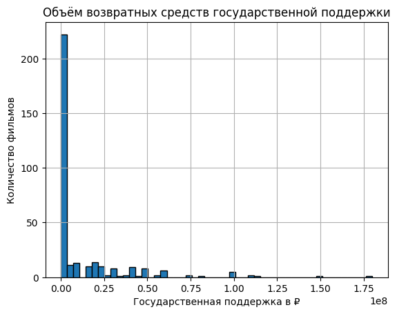

```python
# построим гистограмму с 50 корзинами
mkrf['refundable_support'].hist(edgecolor='black', bins=50)

# обозначим название графика
# назовём оси 'y' и 'x'
plt.title('Объём возвратных средств государственной поддержки')
plt.ylabel('Количество фильмов')
plt.xlabel('Государственная поддержка в ₽')

# выведем на экран
plt.show()
```

Дополним гистограмму числовым описанием данных:

```python
mkrf['refundable_support'].describe()
```

```
count              332.0
mean     11864457.831325
std      24916555.263644
min                  0.0
25%                  0.0
50%                  0.0
75%           15000000.0
max          180000000.0
Name: refundable_support, dtype: Float64
```

- Минимальное значение, первый квартиль и медиана равны **0**. Следует проверить данные на наличие ошибок и установить возможную причину большого количества нулевых значений.
- Среднее выше медианы и составляет **1.1**. Стандартное отклонение — **2.4**. Вероятно, в данных есть аномалии или выбросы.
- Максимальное значение — **180 000 000 ₽**. Можно предположить, что это единичное крупное значение — выброс.

Построим диаграмму размаха, чтобы проверить столбец на наличие выбросов и аномальных значений:

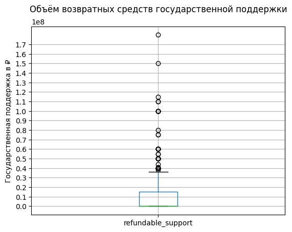

```python
# построим диаграмму размаха по столбцу
mkrf.boxplot(column='refundable_support')

# обозначим название диаграммы, параметром pad настроим высоту заголовка
# поставим метки на оси 'y' с шагом 10_000_000
# назовём ось 'y'
plt.title('Объём возвратных средств государственной поддержки', pad=20)
plt.yticks(range(0, 180_000_000, 10_000_000))
plt.ylabel('Государственная поддержка в ₽')

# выведем на экран
plt.show()
```

- Выбросы почти достигают отметки в `120 000 000`, далее видны особенно крупные значения — `150 000 000` и `180 000 000 рублей`.

Посмотрим на фильмы с нулевым значением в столбце:

```python
# напишем функцию для фильтрации значений
def filtered_data(data, column, value_1, value_2):
    return data[(data[column] >= value_1) & (data[column] <= value_2)]

# выведем результат на экран
filtered_data(mkrf, 'refundable_support', 0, 0)
```

|  | title | pu_number | show_start_date | type | film_studio | production_country | director | producer | age_restriction | refundable_support | nonrefundable_support | budget | financing_source | ratings | genres | box_office |
| --- | --- | --- | --- | --- | --- | --- | --- | --- | --- | --- | --- | --- | --- | --- | --- | --- |
| 6 | небесный верблюд | 111000115 | 2015-01-14 12:00:00+00:00 | Художественный | ооо продюсерский центр "всё хорошо" | Россия | Ю.Фетинг | И.Плиско | «0+» - для любой зрительской аудитории | 0 | 34000000 | 49280496 | Министерство культуры | 6.7 | детский,семейный | 61040 |
| 10 | пилигрим | 111000119 | 2019-02-14 12:00:00+00:00 | Художественный | ооо "чайка синема" | Россия | А.Баршак | М.Гуцериев, Е.Север, Т.Стацман | «16+» - для детей старше 16 лет | 0 | 35000000 | 115000000 | Министерство культуры | 5.3 | триллер | 4293650 |
| 17 | городские птички | 111000216 | 2016-01-15 12:00:00+00:00 | Художественный | ооо "каргофильм" | Россия | Ю.Белюсева | А.Готлиб | «16+» - для детей старше 16 лет | 0 | 25000000 | 38461538 | Министерство культуры | 5.4 | комедия,мелодрама | 355567 |
| 26 | экспириенс | 111000315 | 2015-01-13 12:00:00+00:00 | Художественный | ооо "компания "атк-студио" | Россия | Е.Татаров | А.Тютрюмов | «16+» - для детей старше 16 лет | 0 | 26000000 | 37142857 | Министерство культуры | 4.7 | драма | 36550 |
| 28 | скиф | 111000318 | 2018-01-18 12:00:00+00:00 | Художественный | ооо "кинокомпания "ств" | Россия | Р.Мосафир | С.Сельянов | «18+» - запрещено для детей | 0 | 50000000 | 170122675 | Фонд кино | 6.6 | боевик,фэнтези,драма | 56357981 |
| ... | ... | ... | ... | ... | ... | ... | ... | ... | ... | ... | ... | ... | ... | ... | ... | ... |
| 2137 | урфин джюс возвращается | 114004019 | 2019-10-14 12:00:00+00:00 | Анимационный | ооо "студия анимационного кино "мельница" | Россия | Ф.Дмитриев | С.Сельянов, А.Боярский | «6+» - для детей старше 6 лет | 0 | 200000000 | 300000000 | Фонд кино | 6.2 | мультфильм,детский | 68549523 |
| 2138 | иван царевич и серый волк 3 | 114004115 | 2015-12-24 12:00:00+00:00 | Анимационный | ооо "студия анимационного кино "мельница" | Россия | Д.Шмидт | С.Сельянов, А.Боярский | «6+» - для детей старше 6 лет | 0 | 40000000 | 179257987 | Фонд кино | 6.2 | мультфильм,приключения,семейный | 704928216 |
| 2173 | гофманиада | 114006218 | 2018-09-20 12:00:00+00:00 | Анимационный | фгуп "тпо "киностудия "союзмультфильм" | Россия | С.Соколов | Ю.Слащева, Б.Машковцев, Н.Маковский, С.Струсов... | «12+» - для детей старше 12 лет | 0 | 15000000 | 48238075 | Фонд кино | 6.3 | мультфильм | 2633655 |
| 2176 | баба яга | 114006518 | 2018-11-08 12:00:00+00:00 | Анимационный | ооо "арт пикчерз студия" | Россия | В.Саков | ООО "Арт Пикчерс Студия", ООО "КРИЭЙТИВ АНИМЭЙ... | «6+» - для детей старше 6 лет | 0 | 138969465 | 0 | Фонд кино | NaN | неизвестно | 1334699 |
| 6332 | колобанга. только для пользователей интернета ... | 214010116 | 2016-10-06 12:00:00+00:00 | Анимационный | ооо "колобанга" | Россия | А.Романец | А.Ревва | «0+» - для любой зрительской аудитории | 0 | 11520000 | 18706080 | Министерство культуры | 7.0 | мультфильм,приключения,детектив | <NA> |

221 rows × 16 columns

- Несмотря на отсутствие возвратных средств государственной поддержки, государственные организации, такие как `Министерство культуры` и `Фонд кино`, выделили картинам невозвратные средства поддержки. Также указан бюджет.

В этом случае, значение **0** соответствует действительности. Иногда не требуется возвращать средства государству. Например, если речь идёт о детских фильмах или социально значимом кино.

Посмотрим минимальное значение в столбце, исключив нулевое:

```python
# отфильтруем значения столбца и выведем минимальное
mkrf['refundable_support'][mkrf['refundable_support'] != 0].min()
```

```
3500000
```

Ознакомимся с информацией о фильмах с объёмом возвратных средств государственной поддержки `от 3 500 000 до 5 000 000`:

```python
# выведем результат на экран
filtered_data(mkrf, 'refundable_support', 3_500_000, 5_000_000)
```

|  | title | pu_number | show_start_date | type | film_studio | production_country | director | producer | age_restriction | refundable_support | nonrefundable_support | budget | financing_source | ratings | genres | box_office |
| --- | --- | --- | --- | --- | --- | --- | --- | --- | --- | --- | --- | --- | --- | --- | --- | --- |
| 387 | блокбастер | 111004117 | 2017-05-31 12:00:00+00:00 | Художественный | ооо "хайпфильм" | Россия | Р.Волобуев | И.Стюарт, Ю.Козырев, М.Османн | «16+» - для детей старше 16 лет | 5000000 | 25000000 | 46657311 | Фонд кино | 6.2 | криминал,комедия | 10739479 |
| 612 | проводник | 111006518 | 2018-11-29 12:00:00+00:00 | Художественный | зао "мотор фильм студия" | Россия | И.Максимов | М.Курбатов, Г.Подземельный, Д.Фикс | «16+» - для детей старше 16 лет | 5000000 | 35000000 | 62000000 | Фонд кино | 4.9 | ужасы,триллер | 22730245 |
| 674 | конверт | 111007217 | 2017-11-30 12:00:00+00:00 | Художественный | ооо "рб продакшн" | Россия | В.Марков | К.Буслов | «16+» - для детей старше 16 лет | 5000000 | 30000000 | 74275100 | Фонд кино | 5.6 | триллер,ужасы | 7189790 |
| 744 | сдается дом со всеми неудобствами | 111008016 | 2016-04-27 12:00:00+00:00 | Художественный | фгуп "киноконцерн "мосфильм", ооо "киностудия ... | Россия | В.Сторожева | К.Шахназаров, С.Говорухин | «12+» - для детей старше 12 лет | 3500000 | 20000000 | 69428728 | Фонд кино | 5.8 | комедия | 55800 |
| 1303 | невеста | 111016516 | 2016-10-25 12:00:00+00:00 | Художественный | ооо "форс медиа" | Россия | С.Подгаевский | В.Северцев, Д.Литвинов, З.Болотаев | «16+» - для детей старше 16 лет | 5000000 | 20000000 | 50000000 | Фонд кино | 4.7 | ужасы,триллер | 175799581 |
| 1389 | успех | 111018519 | 2019-11-04 12:00:00+00:00 | Художественный | ооо "кинодом" | Россия | П.Руминов | С.Бобза, Г.Малков, В.Поляков, М.Кучмент | «12+» - для детей старше 12 лет | 5000000 | 20000000 | 75000000 | Фонд кино | 7.8 | драма | 3181218 |
| 1427 | тварь | 111019419 | 2019-11-26 12:00:00+00:00 | Художественный | ооо "сок" | Россия | О.Городецкая | П.Зарукин, О.Филипук, Ф.Ламшин, М.Абрамов, Н.Т... | «16+» - для детей старше 16 лет | 5000000 | 35000000 | 78422212 | Фонд кино | 5.0 | триллер,драма | 18617157 |
| 1475 | 30 свиданий | 111020815 | 2015-12-10 12:00:00+00:00 | Художественный | ооо "инспирейшн фильмз" | Россия | Т.Игуменцева | Д.Литвинов, Д.Осмеркин, А.Гавриш, А.Агеев | «16+» - для детей старше 16 лет | 5000000 | 20000000 | 48661150 | Фонд кино | 5.3 | комедия,мелодрама | 85405424 |
| 2028 | сказ о петре и февронии | 114001517 | 2017-06-06 12:00:00+00:00 | Анимационный | фонд поддержки развития общества "наши дети" | Россия | Ю.Кулаков | Ю.Рязанов, Фонд поддержки развития общества "Н... | «6+» - для детей старше 6 лет | 5000000 | 25000000 | 126932894 | Фонд кино | 6.2 | мультфильм | 48557861 |
| 2111 | бременские разбойники | 114003416 | 2016-11-01 12:00:00+00:00 | Анимационный | ооо "стар медиа дистрибьюшн" | Россия | А.Лукьянчиков, С.Ушаков | ООО "Централ Партнершип", ООО "Стар Медиа Дист... | «6+» - для детей старше 6 лет | 5000000 | 55000000 | 120000000 | Фонд кино | 3.2 | мультфильм,комедия,приключения | 34899699 |

- После фильмов с минимальным значением в `3 500 000` сразу следуют фильмы с объёмом средств — `5 000 000`.
- Запись с минимальным объёмом средств — художественный фильм `'Сдается дом со всеми неудобствами'` от `2016-04-27`, с невысоким рейтингом — `5.8` и маленьким объёмом сборов в рублях — всего `55 800 рублей`.

Несмотря на маленькие сборы, значение вполне реалистично. Неудача фильма в прокате может быть связана с плохой рекламой или слабым сценарием.

Рассчитаем межквартильный размах, чтобы наиболее точно определить верхнюю границу выбросов:

```python
# напишем функцию для расчётов с параметром - столбцом датафрейма
def emission_limit(data, column):

# рассчитаем первый квартиль - 25%
# рассчитаем второй квартиль - 75%
# рассчитаем межквартильный размах - IQR
# вычислим верхнюю границу для выбросов
    Q1 = data[column].quantile(0.25)
    Q3 = data[column].quantile(0.75)
    IQR = Q3 - Q1
    upper_limit = Q3 + 1.5 * IQR
    return f'Верхняя граница выбросов = {upper_limit:.2f}'

# вызовем функцию и выведем результат на экран
emission_limit(mkrf, 'refundable_support')
```

```
'Верхняя граница выбросов = 37500000.00'
```

Согласно расчётам, верхняя граница нормального размаха составляет — `37 500 000 рублей`.

Отфильтруем значения в столбце:

```python
# создадим копию исходного датафрейма
good_mkrf = mkrf.copy()

# отфильтруем строки датафрейма, у которых значение в столбце выше 37_500_000
# оставим строки с NaN в столбце с помощью isna()
good_mkrf = good_mkrf[(mkrf['refundable_support'] <= 37_500_000) | good_mkrf['refundable_support'].isna()]

# проверим результат
good_mkrf['refundable_support'].sort_values(ascending=False)
```

```
1404    36000000
39      35000000
45      30000000
1933    30000000
159     30000000
          ...
7480        <NA>
7481        <NA>
7482        <NA>
7483        <NA>
7484        <NA>
Name: refundable_support, Length: 7445, dtype: Int64
```

Cравним результат предобработки, наложим гистограмму датафрейма до фильтрации — `mkrf` на гистограмму очищенных данных в `good_mkrf`:

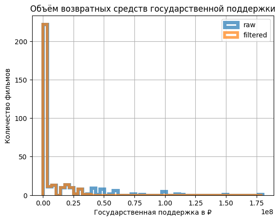

```python
# построим гистограммы на основе исходных данных
ax = mkrf.plot(
    kind='hist',
    y='refundable_support',
    histtype='step',
    range=(0, 180_000_000),
    bins=50,
    linewidth=5,
    alpha=0.7,
    label='raw',
)
# накладываем на гистограмму после предобработки данных
good_mkrf.plot(
    kind='hist',
    y='refundable_support',
    histtype='step',
    range=(0, 180_000_000),
    bins=50,
    linewidth=4,
    alpha=0.7,
    label='filtered',
    ax=ax,
    grid=True,
    legend=True,
)

# дадим название графику и осям
ax.set_title('Объём возвратных средств государственной поддержки')
ax.set_xlabel('Государственная поддержка в ₽')
ax.set_ylabel('Количество фильмов')
```

**Вывод:**

- Оставили нулевые значения в таблице, так как картинам могли выделить другой вид поддержки — невозвратные средства.
- Отфильтровали датафрейм по верхней границе нормального размаха, удалили значения выше `37 500 000 рублей`.
- После фильтрации данных распределение в столбце фатафрейма стало более концентрированным. Это позволит избежать искажений при дальнейшем анализе.

#### Изучение столбца 'nonrefundable_support'

Ознакомимся с гистограммой по столбцу с объёмом невозвратных средств государственной поддержки — `nonrefundable_support`:

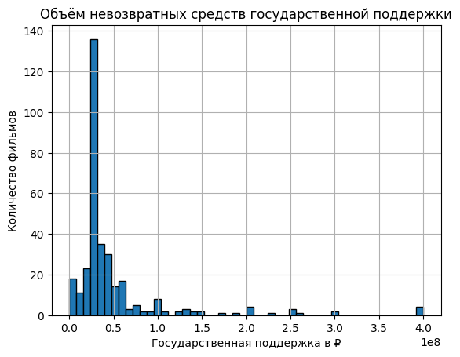

```python
# построим гистограмму с 50 корзинами
mkrf['nonrefundable_support'].hist(edgecolor='black', bins=50)

# обозначим название графика
# назовём оси 'y' и 'x'
plt.title('Объём невозвратных средств государственной поддержки')
plt.ylabel('Количество фильмов')
plt.xlabel('Государственная поддержка в ₽')

# выведем на экран
plt.show()
```

Распределение в столбце с объёмом невозвратных средств государственной поддержки выглядит более равномерно, чем в столбце с возвратными средствами. Однако можно заметить следующие проблемы:

Дополним гистограмму числовым описанием данных:

```python
# выведем числовое описание данных с помощью describe()
mkrf['nonrefundable_support'].describe()
```

```
count              332.0
mean     48980988.891566
std      59980117.923301
min                  0.0
25%           25000000.0
50%           30000000.0
75%           40375000.0
max          400000000.0
Name: nonrefundable_support, dtype: Float64
```

- Среднее выше медианы на **1.8**, достаточно высокое стандартное отклонение — **5.9**. Скорее всего, присутствуют выбросы или аномалии.
- Сомнения вызывает минимальное значение — **0**. Нужно ознакомиться с дополнительной информацией о фильмах с этим значением в столбце.
- Максимальное значение **400 000 000** — похоже на выброс.

Построим диаграмму размаха, чтобы проверить столбец на наличие выбросов и аномальных значений:

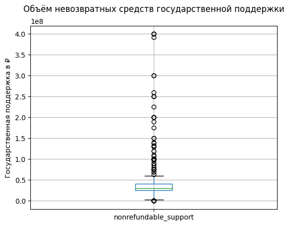

```python
# построим диаграмму размаха по столбцу
mkrf.boxplot(column='nonrefundable_support')

# обозначим название диаграммы, параметром pad настроим высоту заголовка
# назовём ось 'y'
plt.title('Объём невозвратных средств государственной поддержки', pad=20)
plt.ylabel('Государственная поддержка в ₽')

# выведем на экран
plt.show()
```

- Выбросы достигают отметки около `250 000 000 рублей`. Видны отдельные особенно крупные значения — `300 000 000` и `400 000 000 рублей`.
- Можно заметить выброс у нижнего уса на отметке **0**.

Посмотрим, сколько фильмов со значением **0** присутствует в столбце и ознакомимся с дополнительной информацией:

```python
# вызовем функцию и отфильтруем значения
filtered_data(mkrf, 'nonrefundable_support', 0, 0)
```

|  | title | pu_number | show_start_date | type | film_studio | production_country | director | producer | age_restriction | refundable_support | nonrefundable_support | budget | financing_source | ratings | genres | box_office |
| --- | --- | --- | --- | --- | --- | --- | --- | --- | --- | --- | --- | --- | --- | --- | --- | --- |
| 39 | рассвет | 111000419 | 2019-01-31 12:00:00+00:00 | Художественный | ооо "форс медиа" | Россия | П.Сидоров | В.Северцев, Д.Литвинов | «16+» - для детей старше 16 лет | 35000000 | 0 | 56693559 | Фонд кино | 7.3 | ужасы,боевик | 53449712 |
| 141 | кухня. последняя битва | 111001517 | 2017-03-22 12:00:00+00:00 | Художественный | ооо кинокомпания "аврора продакшнз" по заказу ... | Россия | А.Федотов | Э.Илоян, В.Шляппо, Д.Жалинский, А.Троцюк, А.Ку... | «12+» - для детей старше 12 лет | 50000000 | 0 | 162630398 | Фонд кино | 6.0 | комедия | 334007366 |
| 843 | дабл трабл | 111009215 | 2015-05-18 12:00:00+00:00 | Художественный | ооо "таббак", ооо "весёлая компания" | Россия | Э.Оганесян | Т.Бекмамбетов, М.Затуловская | «12+» - для детей старше 12 лет | 44000000 | 0 | 64030080 | Фонд кино | 4.3 | комедия,мелодрама | 19654526 |
| 878 | бармен | 111009615 | 2015-05-26 12:00:00+00:00 | Художественный | ао "вайт медиа", ооо "арт пикчерз студия" | Россия | Д.Штурманова | Т.Вайнштейн | «16+» - для детей старше 16 лет | 20000000 | 0 | 0 | Фонд кино | 6.2 | комедия,фэнтези | 67418975 |
| 1338 | неуловимые: последний герой | 111017415 | 2015-09-30 12:00:00+00:00 | Художественный | ооо "энджой мувиз", ооо "ультра стори" | Россия | А.Аксененко | Г.Малков, В.Поляков, И.Капитонов, В.Муругов | «16+» - для детей старше 16 лет | 25000000 | 0 | 73379554 | Фонд кино | 3.3 | мелодрама,криминал | 11034433 |
| 2107 | три богатыря и принцесса египта | 114003317 | 2017-12-21 12:00:00+00:00 | Анимационный | ооо "студия анимационного кино "мельница" | Россия | К.Феоктистов | С.Сельянов, А.Боярский | «6+» - для детей старше 6 лет | 50000000 | 0 | 174464395 | Фонд кино | 5.5 | мультфильм,приключения,семейный | 759226773 |
| 2118 | крякнутые каникулы | 114003615 | 2015-12-22 12:00:00+00:00 | Анимационный | ооо "анимационная студия рим" | Россия | В.Лакисов | Р.Атоян, В.Зорин, О.Бровченко | «6+» - для детей старше 6 лет | 40000000 | 0 | 399075326 | Фонд кино | 5.4 | мультфильм,комедия,приключения | 69693748 |
| 2161 | иван царевич и серый волк 4 | 114005019 | 2019-12-20 12:00:00+00:00 | Анимационный | ооо "студия анимационного кино "мельница" | Россия | Д.Шмидт, К.Феоктистов | С.Сельянов, А.Боярский | «6+» - для детей старше 6 лет | 100000000 | 0 | 190000000 | Фонд кино | 6.7 | мультфильм,приключения,семейный | 501069235 |
| 2197 | три богатыря и наследница престола | 114008818 | 2018-12-15 12:00:00+00:00 | Анимационный | ооо "студия анимационного кино "мельница" | Россия | К.Бронзит | С.Сельянов, А.Боярский | «6+» - для детей старше 6 лет | 115000000 | 0 | 185500705 | Фонд кино | 6.5 | мультфильм,приключения,семейный | 577368853 |

- Найдено 9 фильмов со значением **0** в столбце.
- Фильм `'Бармен'` с номером прокатного удостоверения **111009615** получил возвратные средства государственной поддержки — `20 000 000`. При этом он не получил невозвратные средства и бюджет составил **0**. Запись выглядит неправдоподобно, так как фильмы, которые получили финансирование от государственных организаций имеют определённый бюджет.
- Остальные фильмы из выборки также получили возвратные средства, но у них бюджет заполнен, поэтому их данные выглядят правдоподобнее. В их случае значение 0 в столбце `nonrefundable_support` не кажется аномалией.

Признаем фильм `Бармен` аномалией и удалим запись из таблицы на этапе фильтрации.

Рассчитаем верхнюю границу нормального размаха:

```python
# вызовем функцию и рассчитаем верхнюю границу выбросов
emission_limit(mkrf, 'nonrefundable_support')
```

```
'Верхняя граница выбросов = 63437500.00'
```

Отфильтруем значения в столбце:

```python
# отфильтруем строки датафрейма, у которых значение в столбце выше 63_437_500
# оставим строки с NaN в столбце с помощью isna()
good_mkrf = good_mkrf[(good_mkrf['nonrefundable_support'] <= 63437500) | good_mkrf['refundable_support'].isna()]

# исключим аномалию со значением 0 в бюджете
good_mkrf = good_mkrf[good_mkrf['pu_number'] != 111009615]

# проверим результат
good_mkrf['nonrefundable_support'].sort_values(ascending=False)
```

```
796     60000000
48      60000000
266     60000000
1397    60000000
1206    60000000
          ...
7480        <NA>
7481        <NA>
7482        <NA>
7483        <NA>
7484        <NA>
Name: nonrefundable_support, Length: 7415, dtype: Int64
```

Cравним результат предобработки, наложим гистограмму датафрейма до фильтрации — `mkrf` на гистограмму очищенных данных в `good_mkrf`:

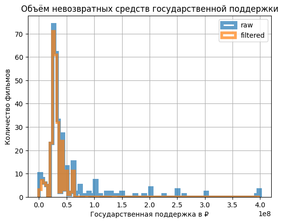

```python
# построим гистограмму на основе исходных данных
ax_2 = mkrf.plot(
    kind='hist',
    y='nonrefundable_support',
    histtype='step',
    range=(0, 400_000_000),
    bins=100,
    linewidth=5,
    alpha=0.7,
    label='raw',
)

# наложим на гистограмму после предобработки данных
good_mkrf.plot(
    kind='hist',
    y='nonrefundable_support',
    histtype='step',
    range=(0, 400_000_000),
    bins=100,
    linewidth=4,
    alpha=0.7,
    label='filtered',
    ax=ax_2,
    grid=True,
    legend=True,
)

# дадим название графику и осям
ax_2.set_title('Объём невозвратных средств государственной поддержки')
ax_2.set_xlabel('Государственная поддержка в ₽')
ax_2.set_ylabel('Количество фильмов')
```

**Выводы:**

- Удалили строку с аномальным значением из датафрейма `good_mkrf`.
- Отфильтровали значения выше `63 437 500 рублей` по верхней границе нормального размаха.
- В результате фильтрации исчез длинный хвост, распределение стало более концентрированным.

#### Изучение столбца 'budget'

Ознакомимся с гистограммой по столбцу с общим бюджетом фильма — `budget`:

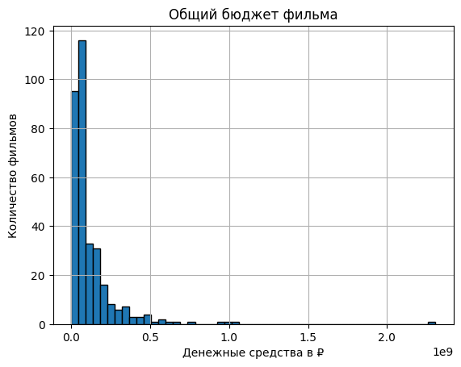

```python
# построим гистограмму с 50 корзинами
mkrf['budget'].hist(edgecolor='black', bins=50)

# обозначим название графика
# назовём оси 'y' и 'x'
plt.title('Общий бюджет фильма')
plt.ylabel('Количество фильмов')
plt.xlabel('Денежные средства в ₽')

# выведем на экран
plt.show()
```

- На гистограмме видно два пика, большая часть данных сконцентрирована у минимальных значений.
- Заметен небольшой хвост примерно до отметки в `700 000 000 рублей`. Далее — отдельные крупные значения около `1 000 000 000` и `2 000 000 000`.

Дополним гистограмму числовым описанием данных:

```python
# выведем числовое описание данных столбца
mkrf['budget'].describe()
```

```
count               332.0
mean     127229716.683735
std      188588333.115158
min                   0.0
25%            42000000.0
50%            68649916.0
75%           141985319.5
max          2305074303.0
Name: budget, dtype: Float64
```

Проверим данные в столбце на наличие выбросов, построим диаграмму размаха:

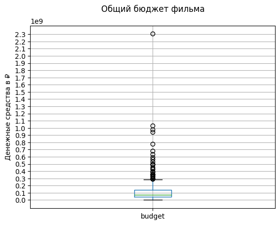

```python
# построим диаграмму размаха по столбцу
mkrf.boxplot(column='budget')

# обозначим название диаграммы, параметром pad настроим высоту заголовка
# назовём ось 'y'
# проставим метки на оси 'y' с шагом 100 000 000
plt.title('Общий бюджет фильма', pad=20)
plt.ylabel('Денежные средства в ₽')
plt.yticks(range(0, 2_305_074_303, 100_000_000))

# выведем на экран
plt.show()
```

- Выбросы достигают отметки в `1 000 000 000 рублей`.
- Видно выброс, одно особенно крупное значение — `2 305 074 303 рублей`.

Посмотрим дополнительную информацию о фильмах с бюджетом **0**:

```python
filtered_data(good_mkrf, 'budget', 0, 0)
```

|  | title | pu_number | show_start_date | type | film_studio | production_country | director | producer | age_restriction | refundable_support | nonrefundable_support | budget | financing_source | ratings | genres | box_office |
| --- | --- | --- | --- | --- | --- | --- | --- | --- | --- | --- | --- | --- | --- | --- | --- | --- |
| 405 | мифы | 111004317 | 2017-06-07 12:00:00+00:00 | Художественный | ооо "хайпфильм", ооо "арт пикчерз студия" | Россия | А.Молочников | Ф.Бондарчук, Д.Рудовский, И.Стюарт, М.Османн, ... | «16+» - для детей старше 16 лет | 25000000 | 20000000 | 0 | Фонд кино | 4.8 | комедия | 50451949 |
| 462 | помню не помню! | 111004916 | 2016-03-01 12:00:00+00:00 | Художественный | ооо "кинофирма" | Россия | В.Ровенский | неизвестно | «12+» - для детей старше 12 лет | 0 | 6000000 | 0 | Министерство культуры | 4.3 | комедия | 15362931 |
| 761 | любовь с ограничениями | 111008216 | 2016-04-29 12:00:00+00:00 | Художественный | ао "вайт медиа", ооо "арт пикчерз студия" | Россия | Д.Тюрин | Ф.Бондарчук, Т.Вайнштейн, Д.Рудовский | «16+» - для детей старше 16 лет | 19000000 | 51000000 | 0 | Фонд кино | 6.3 | комедия,мелодрама | 70299052 |
| 930 | тряпичный союз | 111010215 | 2015-06-08 12:00:00+00:00 | Художественный | ооо "кинокомпания "коктебель" | Россия | М.Местецкий | Р.Борисевич, А.Кушаев | «18+» - запрещено для детей | 0 | 59000000 | 0 | Фонд кино | 6.3 | комедия,драма | 1957739 |
| 1075 | селфи | 111012117 | 2018-02-01 12:00:00+00:00 | Художественный | ооо "киностудия "слово", ооо "арт пикчерз студия" | Россия | Н.Хомерики | П.Ануров, Ф.Бондарчук, Д.Рудовский | «16+» - для детей старше 16 лет | 20000000 | 40000000 | 0 | Фонд кино | 5.8 | триллер,драма | 225196400 |
| 1325 | срочно выйду замуж | 111017115 | 2015-09-30 12:00:00+00:00 | Художественный | ао "вайт медиа", ооо "арт пикчерз студия" | Россия | С Чекалов | Ф.Бондарчук, Т.Вайнштейн, Д.Рудовский | «16+» - для детей старше 16 лет | 0 | 35000000 | 0 | Фонд кино | 5.1 | комедия,мелодрама | 72937783 |
| 1554 | 14+ | 111023614 | 2014-12-19 12:00:00+00:00 | Художественный | ооо киностудия "сентябрь" | Россия | А.Зайцев | О.Гранина, А.Зайцев | «16+» - для детей старше 16 лет | 0 | 23000000 | 0 | Министерство культуры, Фонд кино | 6.6 | мелодрама | 10234016 |
| 2001 | два хвоста | 114001018 | 2018-05-31 12:00:00+00:00 | Анимационный | ооо "лицензионные бренды" | Россия | В.Ровенский, Н.Лопато, В.Азеев | ООО "ЛИЦЕНЗИОННЫЕ БРЕНДЫ" | «6+» - для детей старше 6 лет | 10000000 | 60000000 | 0 | Фонд кино | 5.0 | мультфильм,детский | 106514301 |
| 2040 | чудо-юдо | 114001817 | 2017-06-27 12:00:00+00:00 | Анимационный | ооо "кинофирма" | Россия | А.Лукичев | ООО "КиноФирма" | «6+» - для детей старше 6 лет | 20000000 | 20000000 | 0 | Фонд кино | 5.2 | мультфильм,фэнтези,семейный | 55108015 |

Можно предположить, что данные в столбце остались незаполнены в результате ошибки. Удалим такие фильмы из датафрейма, чтобы избежать некорректных результатов в ходе дальнейших расчётов.

Посмотрим дополнительную информацию о фильмах с бюджетом в диапазоне от `2 000 000 000` до `2 500 000 000 рублей`:

```python
filtered_data(mkrf, 'budget', 2_000_000_000, 2_500_000_000)
```

|  | title | pu_number | show_start_date | type | film_studio | production_country | director | producer | age_restriction | refundable_support | nonrefundable_support | budget | financing_source | ratings | genres | box_office |
| --- | --- | --- | --- | --- | --- | --- | --- | --- | --- | --- | --- | --- | --- | --- | --- | --- |
| 1115 | тайна печати дракона | 111012819 | 2019-09-12 12:00:00+00:00 | Художественный | ооо "кинокомпания "ств"; ооо "рфг корп"; ооо "... | Россия-Китай | О.Степченко | С.Сельянов, А.Петрухин | «6+» - для детей старше 6 лет | 180000000 | 90000000 | 2305074303 | Фонд кино | 5.8 | приключения,фэнтези | 333597060 |

- Найден 1 художественный фильм — `Тайна печати дракона` от 2019.09.12. Фильм получил как возвратные — `180 000 000`, так и невозвратные средства поддержки — `90 000 000`. Бюджет картины составляет `2 305 074 303 рублей`.

Рассчитаем окупаемость фильма:

```python
# сохраним в переменную film выбранную строку
film = mkrf[mkrf['pu_number'] == 111012819]

# сохраним общий бюджет фильма
full_budget = film['budget'].sum()

# сохраним сборы фильма
box_office_movie = film['box_office'].sum()

# рассчитаем окупаемость
payback = box_office_movie / full_budget

# округлим результат до 2 знаков после запятой и выведем на экран
print(round(payback * 100, 1), '%')
```

```
14.5 %
```

Окупаемость фильма составляет всего 14.5 %, что говорит о неудаче фильма в прокате.

Крупное значение в столбце можно назвать реалистичным, однако оно редкое и может смещать среднее вверх в ходе анализа, поэтому признаем его выбросом.

Рассчитаем верхнюю границу выбросов наиболее точно:

```python
# вызовем функцию и рассчитаем верхнюю границу нормального размаха
emission_limit(mkrf, 'budget')
```

```
'Верхняя граница выбросов = 291963298.75'
```

Отфильтруем данные в столбце:

```python
# # отфильтруем строки датафрейма
# оставим строки с NaN в столбце с помощью isna()
# удалим строки со значением 0 в столбце budget
good_mkrf = good_mkrf[
    ((good_mkrf['budget'] <= 291963298.75) & (good_mkrf['budget'] != 0)) |
    (good_mkrf['budget'].isna())
]

# проверим результат
good_mkrf['budget'].sort_values(ascending=False)
```

```
1267    287802711
1933    252489571
188     222513841
2071    219398491
1504    215860000
          ...
7480         <NA>
7481         <NA>
7482         <NA>
7483         <NA>
7484         <NA>
Name: budget, Length: 7400, dtype: Int64
```

Cравним результат предобработки, наложим гистограмму датафрейма до фильтрации — `mkrf` на гистограмму очищенных данных в `good_mkrf`:

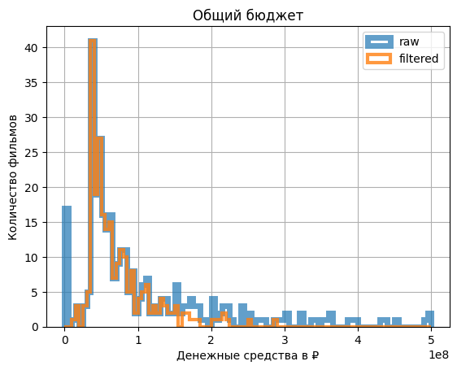

```python
# построим гистограммы на основе исходных данных
ax_3 = mkrf.plot(
    kind='hist',
    y='budget',
    histtype='step',
    range=(0, 500_000_000),
    bins=100,
    linewidth=5,
    alpha=0.7,
    label='raw',
)

# накладываем на гистограмму после предобработки данных
good_mkrf.plot(
    kind='hist',
    y='budget',
    histtype='step',
    range=(0, 500_000_000),
    bins=100,
    linewidth=3,
    alpha=0.8,
    label='filtered',
    ax=ax_3,
    grid=True,
    legend=True,
)

# дадим название графику и осям
ax_3.set_title('Общий бюджет')
ax_3.set_xlabel('Денежные средства в ₽')
ax_3.set_ylabel('Количество фильмов')
```

**Выводы:**

- Очистили датафрейм от строк со значением **0** в столбце `budget`, удалили выбросы в соответствии с верхней границей номального размаха.
- В результате предобработки распределение стало более равномерным и концентрированным.

#### Изучение столбца 'box_office'

Ознакомимся с гистограммой по столбцу со сборами в рублях — `box_office`:

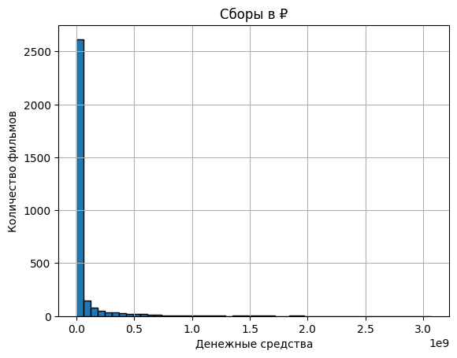

```python
# построим гистограмму с 50 корзинами
mkrf['box_office'].hist(edgecolor='black', bins=50)

# обозначим название графика
# назовём оси 'y' и 'x'
plt.title('Сборы в ₽')
plt.ylabel('Количество фильмов')
plt.xlabel('Денежные средства')

# выведем на экран
plt.show()
```

- На гистограмме заметен высокий пик у значения **0**, а также длинный узкий хвост почти до `2 000 000 000 рублей`.

Дополним гистограмму числовым описанием данных:

```python
# выведем числовое описание данных
mkrf['box_office'].describe()
```

```
count              3158.0
mean      76478696.164978
std      240353122.825983
min                   0.0
25%               86239.0
50%             2327987.5
75%           23979671.25
max          3073568691.0
Name: box_office, dtype: Float64
```

- Среднее выше медианы на **5.3**, а стандартное отклонение составляет **2.4**. Значит, в данных есть выбросы.
- Минимальное значение составляет **0**, а максимальное — **3 000 000 000**. Нужно проверить информацию о фильмах с такими значениями.

Проверим данные в столбце на наличие выбросов, построим диаграмму размаха:

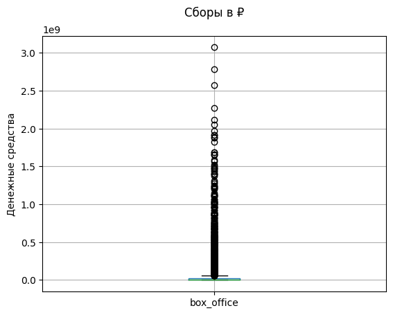

```python
# построим диаграмму размаха по столбцу
mkrf.boxplot(column='box_office')

# обозначим название диаграммы, параметром pad настроим высоту заголовка
# назовём ось 'y'
plt.title('Сборы в ₽', pad=20)
plt.ylabel('Денежные средства')

# выведем на экран
plt.show()
```

- Выбросы достигают приблизительной отметки в `2 200 000 000 рублей`. Видно несколько особенно крупных значений от `2 500 000 000` до `3 000 000 000 рублей`.

Ознакомимся с информацией о фильмах со значением **0** в столбце `box_office`:

```python
filtered_data(mkrf, 'box_office', 0, 0)
```

|  | title | pu_number | show_start_date | type | film_studio | production_country | director | producer | age_restriction | refundable_support | nonrefundable_support | budget | financing_source | ratings | genres | box_office |
| --- | --- | --- | --- | --- | --- | --- | --- | --- | --- | --- | --- | --- | --- | --- | --- | --- |
| 144 | москва, я люблю тебя | 111001610 | 2010-02-09 12:00:00+00:00 | Художественный | ооо "бфг-медиа-продакшн", ооо "продюсерская ко... | Россия | Г.Михалков, Г.Натансон, В.Сторожева, А.Касатки... | Ю.Глоцер, Ю.Гинзбург | «16+» - для детей старше 16 лет | <NA> | <NA> | <NA> | неизвестно | 4.5 | мелодрама,комедия | 0 |
| 186 | поездка к матери | 111002015 | 2015-03-02 12:00:00+00:00 | Художественный | зао "киностудия "м"-фильм" | Россия | М.Косырев-Нестеров | М.Косырев-Нестеров | «16+» - для детей старше 16 лет | <NA> | <NA> | <NA> | неизвестно | NaN | драма,семейный | 0 |
| 225 | весёлые ребята ;) | 111002414 | 2014-02-27 12:00:00+00:00 | Художественный | зао "продюсерская компания валерия тодоровского" | Россия | А.Бобров | В.Тодоровский | «6+» - для детей старше 6 лет | <NA> | <NA> | <NA> | неизвестно | NaN | неизвестно | 0 |
| 280 | запах вереска | 111003012 | 2012-05-23 12:00:00+00:00 | Художественный | ооо "студия рим" | Россия | А.Магомедов | М.Балашова, Е.Миронов | «16+» - для детей старше 16 лет | <NA> | <NA> | <NA> | неизвестно | 6.3 | комедия | 0 |
| 549 | красный лед. сага о хантах югры | 111005910 | 2010-06-04 12:00:00+00:00 | Художественный | департамент культуры и искусства хмао-югры, оо... | Россия | О.Фесенко | О.Урушев | «16+» - для детей старше 16 лет | <NA> | <NA> | <NA> | неизвестно | 4.5 | драма,история | 0 |
| 625 | марафон | 111006712 | 2012-12-18 12:00:00+00:00 | Художественный | ооо "синема арт студио" | Россия | К.Оганесян | К.Оганесян | «16+» - для детей старше 16 лет | <NA> | <NA> | <NA> | неизвестно | 5.5 | комедия,мелодрама | 0 |
| 664 | кино про алексеева | 111007114 | 2014-07-18 12:00:00+00:00 | Художественный | ооо "кинокомпания "новые люди" | Россия | М.Сегал | Н.Мокрицкая | «12+» - для детей старше 12 лет | <NA> | <NA> | <NA> | неизвестно | 6.9 | драма | 0 |
| 706 | подранки | 111007613 | 2013-10-18 12:00:00+00:00 | Художественный | киностудия "мосфильм" | СССР | Н.Губенко | неизвестно | «12+» - для детей старше 12 лет | <NA> | <NA> | <NA> | неизвестно | 8.2 | драма | 0 |
| 877 | курбан-роман. (история с жертвой) | 111009614 | 2014-09-02 12:00:00+00:00 | Художественный | фонд "инновация" | Россия | С.Юзеев | М.Галицкая | «12+» - для детей старше 12 лет | <NA> | <NA> | <NA> | неизвестно | NaN | неизвестно | 0 |
| 896 | пусть так будет | 111009815 | 2015-06-01 12:00:00+00:00 | Художественный | ооо продюсерская компания "держава" | Россия | О.Смольников | К.Лавров, Ю.Потапова, В.Бутер, С.Прудников, С.... | «12+» - для детей старше 12 лет | <NA> | <NA> | <NA> | неизвестно | NaN | неизвестно | 0 |
| 988 | анна павлова | 111011013 | 2013-12-19 12:00:00+00:00 | Художественный | совместное производство киностудия "мосфильм",... | СССР-Франция-Англия-Куба-ГДР | Эмиль Лотяну | неизвестно | «6+» - для детей старше 6 лет | <NA> | <NA> | <NA> | неизвестно | 7.7 | драма,биография,музыка | 0 |
| 1174 | звездный мальчик | 111013915 | 2015-08-25 12:00:00+00:00 | Художественный | киностудия "мосфильм" | СССР | Е.Зильберштейн, А.Дудоров | неизвестно | «0+» - для любой зрительской аудитории | <NA> | <NA> | <NA> | неизвестно | 7.5 | драма | 0 |
| 1326 | ананас | 111017116 | 2016-11-10 12:00:00+00:00 | Художественный | рудак владимир иванович | Россия | В.Рудак | В.Рудак, А.Бабенко | «16+» - для детей старше 16 лет | <NA> | <NA> | <NA> | неизвестно | 6.7 | боевик,комедия,криминал | 0 |
| 2462 | последняя любовь мистера моргана /по роману фр... | 121002614 | 2014-02-11 12:00:00+00:00 | Художественный | камински штим фильм, бавария пикчерз, сенатор ... | Германия-Бельгия-США-Франция | Сандра Неттельбек | Франк Камински, Астрид Камке, Филипп Кройцер, ... | «16+» - для детей старше 16 лет | <NA> | <NA> | <NA> | неизвестно | 6.9 | драма | 0 |
| 3056 | стать джоном ленноном | 121008610 | 2010-05-05 12:00:00+00:00 | Художественный | авер медиа, экосси фильмз, фильм 4, норс вест ... | Канада-Великобритания | Сэм Тейлор Вуд | Роберт Бернштейн, Кевин Лоудер, Дуглас Рэй | «16+» - для детей старше 16 лет | <NA> | <NA> | <NA> | неизвестно | 7.5 | драма,мелодрама,биография | 0 |
| 3358 | прогулка по солнечному свету | 121011614 | 2014-06-11 12:00:00+00:00 | Художественный | вертиго фильмз, айэм глобал | Великобритания | Макс Джива, Дания Пасквини | Кэролайн Леви, Эллан Нибло, Джеймс Ричардсон | «12+» - для детей старше 12 лет | <NA> | <NA> | <NA> | неизвестно | 6.1 | мюзикл,драма,мелодрама | 0 |
| 3497 | люблю твою жену | 121013014 | 2014-06-23 12:00:00+00:00 | Художественный | серендипити пойнт фильм, номадик пикчерз | Канада | Джеримайя С.Чечик | Стефен Аликс, Эри Лантос, Роберт Лантош | «16+» - для детей старше 16 лет | <NA> | <NA> | <NA> | неизвестно | 6.0 | мелодрама,комедия | 0 |
| 3654 | экзамен для двоих /по роману джин ханфф корелитц | 121014613 | 2013-06-11 12:00:00+00:00 | Художественный | депф оф филд | США | Пол Вайц | Пол Вайц, Керри Кохански, Эндрю Миано | «12+» - для детей старше 12 лет | <NA> | <NA> | <NA> | неизвестно | 5.8 | мелодрама,комедия,драма | 0 |
| 4202 | дерево | 121020210 | 2010-11-03 12:00:00+00:00 | Художественный | ле фильм дю позьон, тейлор медиа, скрин ауастр... | Франция-Австралия | Жюли Бертучелли | неизвестно | «16+» - для детей старше 16 лет | <NA> | <NA> | <NA> | неизвестно | NaN | неизвестно | 0 |
| 4876 | в тумане /по одноименной повести василя быкова | 121027712 | 2012-11-07 12:00:00+00:00 | Художественный | ма йа де фикшн, лемминг фильм, беларусьфильм, ... | Германия-Нидерланды-Беларусь-Россия-Латвия | Сергей Лозница | Хайно Декерт | «12+» - для детей старше 12 лет | <NA> | <NA> | <NA> | неизвестно | 6.5 | драма,военный,история | 0 |
| 5131 | анжелика, маркиза ангелов | 121031913 | 2013-12-12 12:00:00+00:00 | Художественный | европа корп., монафильм, вилмафильм | Франция | Ариэль Зейтун | Эммануэль Жаклин, Павел Солк, Филипп Херинг | «16+» - для детей старше 16 лет | <NA> | <NA> | <NA> | неизвестно | 8.0 | драма,мелодрама,приключения | 0 |
| 5572 | летние войны | 124002812 | 2012-10-25 12:00:00+00:00 | Анимационный | медхауз, ниппон телевижн нетуорк корпорейшн, к... | Япония | Мамору Хосода | Такафуми Ватанабэ, Такуя Ито, Сэйдзи Окуда, Юи... | «12+» - для детей старше 12 лет | <NA> | <NA> | <NA> | неизвестно | 7.7 | аниме,мультфильм,фантастика | 0 |
| 5580 | письмо для момо | 124002912 | 2012-10-25 12:00:00+00:00 | Анимационный | кадокава пикчерз, продакшнз и джи, токио броуд... | Япония | Окиура Хироюки | Хироюки Икеда, Митсухиса Ишикава, Кацзуя Хамана | «12+» - для детей старше 12 лет | <NA> | <NA> | <NA> | неизвестно | 7.4 | аниме,мультфильм,драма | 0 |
| 6221 | гарегин нжде | 131000213 | 2013-04-23 12:00:00+00:00 | Художественный | ей джи кей продакшнз, пан армениан медиа груп | Армения | Грач Кешишян | Грач Кешишян | «12+» - для детей старше 12 лет | <NA> | <NA> | <NA> | неизвестно | 7.9 | биография | 0 |

- Найдено 24 фильма, из которых 22 — художественные и 2 — анимационные.

Рассчитаем средний рейтинг таких фильмов:

```python
# отфильтруем строки со значением 0 в столбце box_office и посчитаем среднее
# округлим значение до 1 знака после запятой
mkrf[mkrf['box_office'] == 0 ]['ratings'].mean().round(1)
```

```
6.7
```

Средний рейтинг фильмов составляет **6.7**. Среди жанров преобладает драма. У всех фильмов отсутствует государственная поддержка. Можно предположить, что источниками финансирования являются коммерческие организации.

Отсутствие данных о сборах и наличие рейтинга можно объяснить несколькими факторами. Например, эти фильмы могли быть выпущены на стриминговых площадках или показаны на кинофестивалях. Также возможно, что фильмы были выпущены за рубежом — например, в Японии или США, и информация о сборах не была занесена в эту базу данных.

Хотя можно объяснить происхождение нулевых значений в столбце со сборами фильмов, мы отфильтруем такие строки из датафрейма для более корректных расчётов и результатов исследования.

Ознакомимся с информацией о фильмах со сборами в диапазоне `от 2 000 000 000 до 3 000 000 000 рублей`:

```python
filtered_data(mkrf, 'box_office', 2_000_000_000, 3_000_000_000)
```

|  | title | pu_number | show_start_date | type | film_studio | production_country | director | producer | age_restriction | refundable_support | nonrefundable_support | budget | financing_source | ratings | genres | box_office |
| --- | --- | --- | --- | --- | --- | --- | --- | --- | --- | --- | --- | --- | --- | --- | --- | --- |
| 1054 | движение вверх | 111011817 | 2017-12-21 12:00:00+00:00 | Художественный | ооо "студия "тритэ" никиты михалкова" | Россия | А.Мегердичев | Л.Верещагин, А.Златопольский, Н.Михалков, ООО ... | «6+» - для детей старше 6 лет | 0 | 400000000 | 590192191 | Фонд кино | 7.5 | спорт,драма | 2779686144 |
| 1579 | т-34 | 111024918 | 2018-12-21 12:00:00+00:00 | Художественный | ооо "кинокомпания марс-фильм" по заказу ооо "м... | Россия | А.Сидоров | А.Златопольский, Р.Дишдишян, Л.Блаватник, Н.Яр... | «12+» - для детей старше 12 лет | 60000000 | 120000000 | 563784717 | Фонд кино | 6.5 | драма,военный,боевик | 2271754005 |
| 2755 | мстители: финал | 121005519 | 2019-04-29 12:00:00+00:00 | Художественный | марвел студиоз | США | Джо Руссо, Энтони Руссо | Кевин Фейги | «16+» - для детей старше 16 лет | <NA> | <NA> | <NA> | неизвестно | 7.6 | фантастика,боевик,драма | 2576613777 |
| 3123 | пираты карибского моря: мертвецы не рассказыва... | 121009217 | 2017-05-17 12:00:00+00:00 | Художественный | джерри брукхайэмер фильмз, уолт дисней пикчерз... | США | Йоаким Реннинг, Эспен Сандберг | Джерри Брукхаймер | «16+» - для детей старше 16 лет | <NA> | <NA> | <NA> | неизвестно | 6.6 | фэнтези,боевик,комедия | 2118396119 |
| 5339 | зверополис | 124000316 | 2016-02-15 12:00:00+00:00 | Анимационный | уолт дисней анимейшн студиоз, уолт дисней пикчерз | США | Рич Мур, Байрон Ховард | Кларк Спенсер | «6+» - для детей старше 6 лет | <NA> | <NA> | <NA> | неизвестно | 8.3 | мультфильм,комедия,криминал | 2048126108 |

- В таблице найдёно **5** фильмов: **3** из них было снято в США, **2** — в России.

Дополнительная информация выглядит правдоподобно, но в датафрейме мало записей с такими крупными сборами. Поэтому мы отфильтруем их для более корректного анализа.

Рассчитаем верхнюю границу нормального размаха:

```python
emission_limit(mkrf, 'box_office')
```

```
'Верхняя граница выбросов = 59819819.62'
```

Отфильтруем данные:

```python
# отфильтруем строки датафрейма, у которых значение в столбце выше 59_819_819
# оставим строки с NaN в столбце с помощью isna()
# отфильтруем строки с 0 в box_office
good_mkrf = good_mkrf[
    ((good_mkrf['box_office'] <= 59_819_819) & (good_mkrf['box_office'] != 0)) |
    (good_mkrf['box_office'].isna())
]

# проверим результат
good_mkrf['box_office'].sort_values(ascending=False)
```

```
5446    59524891
4811    59431246
4818    59242029
3741    58778318
4004    58351843
          ...
7480        <NA>
7481        <NA>
7482        <NA>
7483        <NA>
7484        <NA>
Name: box_office, Length: 6889, dtype: Int64
```

Cравним результат предобработки, наложим гистограмму датафрейма до фильтрации — `mkrf` на гистограмму очищенных данных в `good_mkrf`:

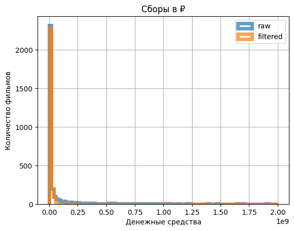

```python
# построим гистограммы на основе исходных данных
ax_4 = mkrf.plot(
    kind='hist',
    y='box_office',
    histtype='step',
    range=(0, 2_000_000_000),
    bins=100,
    linewidth=5,
    alpha=0.7,
    label='raw',
)

# накладываем на гистограмму после предобработки данных
good_mkrf.plot(
    kind='hist',
    y='box_office',
    histtype='step',
    range=(0, 2_000_000_000),
    bins=100,
    linewidth=5,
    alpha=0.7,
    label='filtered',
    ax=ax_4,
    grid=True,
    legend=True,
)

# дадим название графику и осям
ax_4.set_title('Сборы в ₽')
ax_4.set_ylabel('Количество фильмов')
ax_4.set_xlabel('Денежные средства')
```

**Выводы:**

- Отфильтровали нулевые значения в столбце `box_office`, а также выбросы по верхней границе нормального размаха.
- Распределение на гистограмме выглядит более концентрировано, убрали длинный хвост с особенно крупными значениями.

### Категоризация данных

Создадим столбец с информацией о годе проката. Выделим год из даты премьеры фильма:

```python
# отключим предупреждение SettingWithCopyWarning, так как good_mkrf это уже копия исходного mkrf
pd.options.mode.chained_assignment = None

# выделим год из даты с помощью dt.year
good_mkrf['release_year'] = good_mkrf['show_start_date'].dt.year

# проверим результат
good_mkrf.head()
```

|  | title | pu_number | show_start_date | type | film_studio | production_country | director | producer | age_restriction | refundable_support | nonrefundable_support | budget | financing_source | ratings | genres | box_office | release_year |
| --- | --- | --- | --- | --- | --- | --- | --- | --- | --- | --- | --- | --- | --- | --- | --- | --- | --- |
| 0 | 1001 рецепт влюбленного кулинара | 1811096 | 2010-12-23 12:00:00+00:00 | Художественный | ле фильм дю риваж, ля сет синема, адам и ева, ... | Франция-Грузия-Германия-Россия-Украина-Бельгия | Н.Джорджадзе | неизвестно | «0+» - для любой зрительской аудитории | <NA> | <NA> | <NA> | неизвестно | 6.7 | мелодрама,комедия | <NA> | 2010 |
| 1 | небесный тихоход (новая цветная версия) | 111000110 | 2010-01-14 12:00:00+00:00 | Художественный | киностудия "ленфильм", зао "киновидеообъединен... | СССР-Россия | И.Цветов (режиссер ч/б фильма - С.Тимошенко) | ЗАО "Киновидеообъединение "Крупный план" | «0+» - для любой зрительской аудитории | <NA> | <NA> | <NA> | неизвестно | 8.0 | комедия,военный | <NA> | 2010 |
| 2 | и не было лучше брата | 111000111 | 2011-01-13 12:00:00+00:00 | Художественный | ооо "ибрус" при поддержке киностудии "азербай... | Россия-Азербайджан | М.Ибрагимбеков | М.Ибрагимбеков, А.Швыдкой, Д.Шуфутинский | «16+» - для детей старше 16 лет | <NA> | <NA> | <NA> | неизвестно | 6.7 | детектив | <NA> | 2011 |
| 3 | детский юмористический киножурнал "ералаш", вы... | 111000112 | 2012-01-16 12:00:00+00:00 | Художественный | ооо "ералаш" | Россия | В.Панжев, Г.Курлаев, И.Белостоцкий, М.Сулейман... | ООО "Ералаш" | «0+» - для любой зрительской аудитории | <NA> | <NA> | <NA> | неизвестно | 7.2 | детский,комедия | <NA> | 2012 |
| 4 | тайна перевала дятлова | 111000113 | 2013-01-17 12:00:00+00:00 | Художественный | ооо "нон-стоп продакшн" | Россия | Ренни Харлин | А.Роднянский, С.Мелькумов, С.Беспалов, Киа Джэм | «16+» - для детей старше 16 лет | <NA> | <NA> | <NA> | неизвестно | 5.1 | ужасы,фантастика | 2450 | 2013 |

Создадим два столбца: с именем и фамилией главного режиссёра и основным жанром фильма. В столбцы войдут первые значения из списка режиссёров и жанров.

```python
# напишем функцию для создания 2 новых столбцов
# разобьём строки на списки элементов в выбранных столбцах, выберем первый элемент
# вернём Series, чтобы создать 2 колонки сразу
def main_genre_and_director(row):
    main_director = row['director'].split(',')[0]
    main_genre = row['genres'].split(',')[0]
    return pd.Series([main_director, main_genre], index=['main_director', 'main_genre'])

# вызовем функцию с помощью apply()
good_mkrf[['main_director', 'main_genre']] = good_mkrf.apply(main_genre_and_director, axis=1)

# проверим результат
good_mkrf.tail(40)
```

|  | title | pu_number | show_start_date | type | film_studio | production_country | director | producer | age_restriction | refundable_support | nonrefundable_support | budget | financing_source | ratings | genres | box_office | release_year | main_director | main_genre |
| --- | --- | --- | --- | --- | --- | --- | --- | --- | --- | --- | --- | --- | --- | --- | --- | --- | --- | --- | --- |
| 7445 | кунг-фу панда 2 | 224021411 | 2011-11-15 12:00:00+00:00 | Анимационный | дримуоркс анимейшн | США | Дженнифер Ю | Мелисса Кобб, Джонатан Айбел, Гленн Бергер | «0+» - для любой зрительской аудитории | <NA> | <NA> | <NA> | неизвестно | 7.4 | мультфильм,фэнтези,боевик | 9270 | 2011 | Дженнифер Ю | мультфильм |
| 7446 | кунг-фу панда 2 | 224021511 | 2011-11-16 12:00:00+00:00 | Анимационный | дримуоркс анимейшн | США | Дженнифер Ю | Мелисса Кобб, Джонатан Айбел, Гленн Бергер | «0+» - для любой зрительской аудитории | <NA> | <NA> | <NA> | неизвестно | 7.4 | мультфильм,фэнтези,боевик | <NA> | 2011 | Дженнифер Ю | мультфильм |
| 7447 | ворона-проказница | 224021813 | 2013-09-05 12:00:00+00:00 | Анимационный | аккорд фильм продакшн гмбх, студио 88 | Германия | Зандор Йессе, Уте фон Мюнхов-Поль | Мануэль Аренас | «0+» - для любой зрительской аудитории | <NA> | <NA> | <NA> | неизвестно | 6.0 | мультфильм,комедия,приключения | <NA> | 2013 | Зандор Йессе | мультфильм |
| 7448 | союз зверей /по книге эрика кастнера | 224022410 | 2010-11-18 12:00:00+00:00 | Анимационный | эмбиент интертеймент, константин фильм, уайт х... | Германия | Рейнхард Клоос, Хольгер Таппе | Рейнхард Клоос, Мартин Московиц, Хольгер Таппе... | «0+» - для любой зрительской аудитории | <NA> | <NA> | <NA> | неизвестно | 5.6 | мультфильм,комедия,приключения | 400 | 2010 | Рейнхард Клоос | мультфильм |
| 7449 | шрэк навсегда | 224022910 | 2010-11-16 12:00:00+00:00 | Анимационный | дримуоркс анимейшн, пацификдейт имейджес | США | Майк Митчел | Тереза Ченг, Джина Шэй | «12+» - для детей старше 12 лет | <NA> | <NA> | <NA> | неизвестно | 7.0 | мультфильм,фэнтези,мелодрама | <NA> | 2010 | Майк Митчел | мультфильм |
| 7450 | шрэк /по книге уильяма стейга | 224023010 | 2010-11-16 12:00:00+00:00 | Анимационный | дримуоркс пикчерз, пи ди ай | США | Эндрю Адамсон, Виктория Дженсон | Джон Уильямс, Арон Уорнер | «12+» - для детей старше 12 лет | <NA> | <NA> | <NA> | неизвестно | 8.0 | мультфильм,фэнтези,комедия | <NA> | 2010 | Эндрю Адамсон | мультфильм |
| 7451 | шрэк 2 | 224023110 | 2010-11-16 12:00:00+00:00 | Анимационный | дримуоркс пикчерз, пасифик дата имидж | США | Эндрю Эдамсон, Келли Эсбари | Дэвид Липмен, Джон Г.Уильямс, Эрон Уорнер | «0+» - для любой зрительской аудитории | <NA> | <NA> | <NA> | неизвестно | 7.7 | мультфильм,фэнтези,мелодрама | <NA> | 2010 | Эндрю Эдамсон | мультфильм |
| 7452 | гадкий я | 224023210 | 2010-11-23 12:00:00+00:00 | Анимационный | иллюминейшн интертеймент, юниверсал пикчерз | США | Пьер Коффин, Крис Рено | Джон Коэн, Кристофер Милидандри | «0+» - для любой зрительской аудитории | <NA> | <NA> | <NA> | неизвестно | 7.7 | мультфильм,фэнтези,комедия | 360 | 2010 | Пьер Коффин | мультфильм |
| 7453 | пушистые против зубастых 3d | 224024112 | 2012-11-07 12:00:00+00:00 | Анимационный | анимейшн пикче компани, диджиарт продакшнз, ло... | Южная Корея-США | Кьюнг Хо Ли | Марк а.З.Диппе, Алекс Дж.Йу, Джошуа Сон, Эш Р.... | «6+» - для детей старше 6 лет | <NA> | <NA> | <NA> | неизвестно | 5.2 | мультфильм,приключения,семейный | <NA> | 2012 | Кьюнг Хо Ли | мультфильм |
| 7454 | смывайся ! | 224024611 | 2011-12-27 12:00:00+00:00 | Анимационный | дримуоркс анимейшн, ардман анимейшн | США-Великобритания | Дэвид Боуэрс, Сэм Фелл | Сесил Крамер, Питер Лорд, Дэвид Спрокстон | «0+» - для любой зрительской аудитории | <NA> | <NA> | <NA> | неизвестно | 6.9 | мультфильм,фэнтези,мелодрама | <NA> | 2011 | Дэвид Боуэрс | мультфильм |
| 7455 | в поисках немо | 224024612 | 2012-10-23 12:00:00+00:00 | Анимационный | уолт дисней пикчерз, пиксар, буена виста интер... | США | Ли Анкрич, Эндрю Стентон | Грехем Волтерс | «0+» - для любой зрительской аудитории | <NA> | <NA> | <NA> | неизвестно | 7.9 | мультфильм,комедия,приключения | <NA> | 2012 | Ли Анкрич | мультфильм |
| 7456 | гадкий я 2 | 224024613 | 2013-09-23 12:00:00+00:00 | Анимационный | иллюминейшн интертеймент | США | Пьер Коффин, Крис Рено | Кристофер Меледандри, Джаннет Хили | «0+» - для любой зрительской аудитории | <NA> | <NA> | <NA> | неизвестно | 7.6 | мультфильм,фантастика,фэнтези | <NA> | 2013 | Пьер Коффин | мультфильм |
| 7457 | гадкий я | 224024910 | 2010-11-12 12:00:00+00:00 | Анимационный | иллюминейшн интертеймент, юниверсал пикчерз | США | Пьер Коффин, Крис Рено | Джон Коэн, Кристофер Милидандри | «0+» - для любой зрительской аудитории | <NA> | <NA> | <NA> | неизвестно | 7.7 | мультфильм,фэнтези,комедия | <NA> | 2010 | Пьер Коффин | мультфильм |
| 7458 | шрэк навсегда | 224025010 | 2010-11-12 12:00:00+00:00 | Анимационный | дримуоркс анимейшн, пацификдейт имейджес | США | Майк Митчел | Тереза Ченг, Джина Шэй | «12+» - для детей старше 12 лет | <NA> | <NA> | <NA> | неизвестно | 7.0 | мультфильм,фэнтези,мелодрама | <NA> | 2010 | Майк Митчел | мультфильм |
| 7459 | король лев | 224025412 | 2012-10-23 12:00:00+00:00 | Анимационный | уолт дисней пикчерз, буена виста интернешнл | США | Роб Минкофф, Роджер Аллерс | Дон Хан | «0+» - для любой зрительской аудитории | <NA> | <NA> | <NA> | неизвестно | 8.8 | мультфильм,мюзикл,драма | <NA> | 2012 | Роб Минкофф | мультфильм |
| 7460 | делай ноги | 224026010 | 2010-12-07 12:00:00+00:00 | Анимационный | уорнер бразерс, кингдом фьючер продакшнз, аним... | США-Австралия | Джордж Миллер, Уоррен Коулмэн, Джуди Моррис | Билл Миллер, Джордж Миллер, Даг Митчелл | «0+» - для любой зрительской аудитории | <NA> | <NA> | <NA> | неизвестно | 6.7 | мультфильм,мюзикл,мелодрама | <NA> | 2010 | Джордж Миллер | мультфильм |
| 7461 | полярный экспресс | 224026310 | 2010-12-10 12:00:00+00:00 | Художественный | уорнер бразерс, касл рок интертеймент, шангри-... | США | Роберт Земекис | Стив Старки, Роберт Земекис | «0+» - для любой зрительской аудитории | <NA> | <NA> | <NA> | неизвестно | 7.2 | мультфильм,мюзикл,фэнтези | <NA> | 2010 | Роберт Земекис | мультфильм |
| 7462 | легенды ночных стражей /по мотивам произведени... | 224026410 | 2010-12-10 12:00:00+00:00 | Анимационный | уорнер бразерс, виллидж роудшоу пикчерз | США-Австралия | Зак Снайдер | Зарех Налбандьян | «0+» - для любой зрительской аудитории | <NA> | <NA> | <NA> | неизвестно | 7.5 | мультфильм,фэнтези,боевик | 400 | 2010 | Зак Снайдер | мультфильм |
| 7463 | рапунцель: запутанная история | 224026712 | 2012-10-23 12:00:00+00:00 | Анимационный | уолт дисней анимейшн студиоз, уолт дисней пикчерз | США | Натан Грино, Байрон Ховард | Рой Конли | «12+» - для детей старше 12 лет | <NA> | <NA> | <NA> | неизвестно | 7.9 | мультфильм,мюзикл,фэнтези | <NA> | 2012 | Натан Грино | мультфильм |
| 7464 | гроза муравьев /по мотивам книги джона никла | 224027210 | 2010-12-16 12:00:00+00:00 | Анимационный | уорнер бразерс, плейтоун, ди эн ей продакшнз, ... | США | Джон А.Дэйвис | Гэри Готсман, Джон А.Дэйвис, Том Хэнкс | «0+» - для любой зрительской аудитории | <NA> | <NA> | <NA> | неизвестно | 6.2 | мультфильм,фэнтези,комедия | <NA> | 2010 | Джон А.Дэйвис | мультфильм |
| 7465 | сэмми 2: шевели ластами (шевели ластами 2) | 224027213 | 2013-10-17 12:00:00+00:00 | Анимационный | иллюмината пикчерз, моушн инвестмент груп, эн ... | Бельгия | Бен Стассен | Джина Галло, Мими Мэйнард, Домоник Парис | «0+» - для любой зрительской аудитории | <NA> | <NA> | <NA> | неизвестно | 6.7 | мультфильм,приключения,семейный | <NA> | 2013 | Бен Стассен | мультфильм |
| 7466 | атлантида: затерянный мир | 224027710 | 2010-12-31 12:00:00+00:00 | Анимационный | уолт дисней пикчерз | США | Гэри Траусдейл, Кирк Уайз | Дон Хан | «0+» - для любой зрительской аудитории | <NA> | <NA> | <NA> | неизвестно | 7.8 | мультфильм,фантастика,фэнтези | <NA> | 2010 | Гэри Траусдейл | мультфильм |
| 7467 | рапунцель: запутанная история | 224028210 | 2010-12-31 12:00:00+00:00 | Анимационный | уолт дисней анимейшн студиоз, уолт дисней пикчерз | США | Натан Грино, Байрон Ховард | Рой Конли | «12+» - для детей старше 12 лет | <NA> | <NA> | <NA> | неизвестно | 7.9 | мультфильм,мюзикл,фэнтези | <NA> | 2010 | Натан Грино | мультфильм |
| 7468 | эпик /по произведению уильяма джойса | 224028313 | 2013-11-05 12:00:00+00:00 | Анимационный | хх век фокс, блю скай студиоз | США | Крис Уэдж | Джерри Дэвис, Лори Форте, Джеймс В.Харт | «0+» - для любой зрительской аудитории | <NA> | <NA> | <NA> | неизвестно | 6.9 | мультфильм,фэнтези,приключения | <NA> | 2013 | Крис Уэдж | мультфильм |
| 7469 | братец медвежонок /по одноименному произведени... | 224029312 | 2012-11-19 12:00:00+00:00 | Анимационный | уолт дисней пикчерз, буена виста интернешнл | США | Айрон Блейз, Роберт Уокер | Чак Уильямс | «0+» - для любой зрительской аудитории | <NA> | <NA> | <NA> | неизвестно | 7.9 | мультфильм,фэнтези,комедия | <NA> | 2012 | Айрон Блейз | мультфильм |
| 7470 | вольт | 224029412 | 2012-11-19 12:00:00+00:00 | Анимационный | уолт дисней анимейшн студиоз, уолт дисней пикчерз | США | Крис Уильямс, Байрон Ховард | Кларк Спенсер | «0+» - для любой зрительской аудитории | <NA> | <NA> | <NA> | неизвестно | 7.3 | мультфильм,драма,комедия | <NA> | 2012 | Крис Уильямс | мультфильм |
| 7471 | мулан | 224029712 | 2012-11-19 12:00:00+00:00 | Анимационный | уолт дисней пикчерз | США | Тони Бэнкфорт, Бэрри Кук | Роберт С.Гарбер | «0+» - для любой зрительской аудитории | <NA> | <NA> | <NA> | неизвестно | 6.2 | боевик,фэнтези,драма | <NA> | 2012 | Тони Бэнкфорт | боевик |
| 7472 | новые приключения золушки | 224030212 | 2012-11-19 12:00:00+00:00 | Анимационный | вэнгард фильмз, одиссей интертеймент, берлин а... | США-Германия | Пол Джей Болджер | Джон Эйч Уильямс | «0+» - для любой зрительской аудитории | <NA> | <NA> | <NA> | неизвестно | 5.1 | мультфильм,фэнтези,комедия | <NA> | 2012 | Пол Джей Болджер | мультфильм |
| 7473 | как приручить зомби | 224030612 | 2012-11-27 12:00:00+00:00 | Анимационный | абра продакшнз, диджитал дримз фильм | Испания | Джон Эспинач, Рикардо Рамон | Альберто Геррикабеития | «12+» - для детей старше 12 лет | <NA> | <NA> | <NA> | неизвестно | 4.3 | мультфильм,ужасы,фэнтези | <NA> | 2012 | Джон Эспинач | мультфильм |
| 7474 | мадагаскар 3 | 224031012 | 2012-12-11 12:00:00+00:00 | Художественный | дримуоркс анимейшн | США | Эрик Дарнелл, Том МакГрат, Конрад Вернон | Мирей Сория, Марк Свифт | «0+» - для любой зрительской аудитории | <NA> | <NA> | <NA> | неизвестно | 7.4 | мультфильм,комедия,приключения | <NA> | 2012 | Эрик Дарнелл | мультфильм |
| 7475 | гадкий я 2 | 224033013 | 2013-12-27 12:00:00+00:00 | Анимационный | иллюминейшн интертеймент | США | Пьер Коффин, Крис Рено | Кристофер Меледандри, Джаннет Хили | «0+» - для любой зрительской аудитории | <NA> | <NA> | <NA> | неизвестно | 7.6 | мультфильм,фантастика,фэнтези | <NA> | 2013 | Пьер Коффин | мультфильм |
| 7476 | майкл джексон: вот и всё | 226000110 | 2010-01-20 12:00:00+00:00 | Прочие | коламбиа пикчерз, а и гэ лив, истейт ов майкл ... | США | Кенни Ортега | Пол Гангавар, Рэнди Филипс | «12+» - для детей старше 12 лет | <NA> | <NA> | <NA> | неизвестно | 7.7 | документальный,драма,музыка | <NA> | 2010 | Кенни Ортега | документальный |
| 7477 | кэти перри "акустический концерт" | 226003410 | 2010-01-19 12:00:00+00:00 | Художественный | эм ти ви нетворкс, кэпитол рекордз | Италия | Джесс Гордон | Кайл Уильямс | «12+» - для детей старше 12 лет | <NA> | <NA> | <NA> | неизвестно | 6.9 | документальный,музыка | <NA> | 2010 | Джесс Гордон | документальный |
| 7478 | серфинг на таити 3d | 226006312 | 2012-04-05 12:00:00+00:00 | Документальный | перфект вэйв продакшн инк. | США | Стефан Лоу | Петро Л.Серапиглия | «0+» - для любой зрительской аудитории | <NA> | <NA> | <NA> | неизвестно | 7.2 | документальный | <NA> | 2012 | Стефан Лоу | документальный |
| 7479 | пять препятствий | 226008615 | 2015-09-15 12:00:00+00:00 | Прочие | алмаз фильм продакшн, паник продюксьон, уанбро... | Дания-Швейцария-Бельгия-Франция | Йорген Лет, Ларс Фон Триер | Карстен Холст | «16+» - для детей старше 16 лет | <NA> | <NA> | <NA> | неизвестно | 7.1 | документальный | <NA> | 2015 | Йорген Лет | документальный |
| 7480 | хроника падения | 226014714 | 2014-09-10 12:00:00+00:00 | Прочие | аш би о документари фильмз, фазе 4 фильмз, имп... | США | Люси Уокер | Джулиан Котерли, Адам Пирс, Дженни Раскин, Люс... | «12+» - для детей старше 12 лет | <NA> | <NA> | <NA> | неизвестно | 7.8 | документальный,биография,спорт | <NA> | 2014 | Люси Уокер | документальный |
| 7481 | первый рай | 226017410 | 2010-05-04 12:00:00+00:00 | Прочие | би би си | Великобритания | Дэвид Аттенборо | неизвестно | «0+» - для любой зрительской аудитории | <NA> | <NA> | <NA> | неизвестно | 7.4 | мультфильм,короткометражка,мелодрама | <NA> | 2010 | Дэвид Аттенборо | мультфильм |
| 7482 | дэвид гилмор "римемба зет найт" | 226019110 | 2010-05-14 12:00:00+00:00 | Художественный | дэвид гилмор мьюзик | Великобритания | Дэвид Маллет | Дайоуни Орром | «12+» - для детей старше 12 лет | <NA> | <NA> | <NA> | неизвестно | 7.4 | триллер,драма,детектив | <NA> | 2010 | Дэвид Маллет | триллер |
| 7483 | тотктопрошелсквозьогонь | 231001012 | 2015-04-23 12:00:00+00:00 | Художественный | министерство культуры украины, государственное... | Украина | М.Ильенко | В.Филиппов | «16+» - для детей старше 16 лет | <NA> | <NA> | <NA> | неизвестно | 7.2 | драма,приключения,биография | <NA> | 2015 | М.Ильенко | драма |
| 7484 | мелодия для шарманки | 231001111 | 2011-12-27 12:00:00+00:00 | Художественный | сота синема груп | Украина | Кира Муратова | Олег Кохан | «12+» - для детей старше 12 лет | <NA> | <NA> | <NA> | неизвестно | 6.7 | драма | <NA> | 2011 | Кира Муратова | драма |

Добавим столбец с долей государственной поддержки от общего бюджета фильма:

```python
# сложим возвратные и невозвратные средства гос. поддержки
# разделим сумму на бюджет
# округлим результат и сохраним в столбец state_support_share
good_mkrf['state_support_share_%'] = (
    (good_mkrf['refundable_support'] + good_mkrf['nonrefundable_support'])
    / good_mkrf['budget'] * 100).astype(float).round(1)

# проверим результат
good_mkrf.tail(10)
```

|  | title | pu_number | show_start_date | type | film_studio | production_country | director | producer | age_restriction | refundable_support | nonrefundable_support | budget | financing_source | ratings | genres | box_office | release_year | main_director | main_genre | state_support_share_% |
| --- | --- | --- | --- | --- | --- | --- | --- | --- | --- | --- | --- | --- | --- | --- | --- | --- | --- | --- | --- | --- |
| 7475 | гадкий я 2 | 224033013 | 2013-12-27 12:00:00+00:00 | Анимационный | иллюминейшн интертеймент | США | Пьер Коффин, Крис Рено | Кристофер Меледандри, Джаннет Хили | «0+» - для любой зрительской аудитории | <NA> | <NA> | <NA> | неизвестно | 7.6 | мультфильм,фантастика,фэнтези | <NA> | 2013 | Пьер Коффин | мультфильм | NaN |
| 7476 | майкл джексон: вот и всё | 226000110 | 2010-01-20 12:00:00+00:00 | Прочие | коламбиа пикчерз, а и гэ лив, истейт ов майкл ... | США | Кенни Ортега | Пол Гангавар, Рэнди Филипс | «12+» - для детей старше 12 лет | <NA> | <NA> | <NA> | неизвестно | 7.7 | документальный,драма,музыка | <NA> | 2010 | Кенни Ортега | документальный | NaN |
| 7477 | кэти перри "акустический концерт" | 226003410 | 2010-01-19 12:00:00+00:00 | Художественный | эм ти ви нетворкс, кэпитол рекордз | Италия | Джесс Гордон | Кайл Уильямс | «12+» - для детей старше 12 лет | <NA> | <NA> | <NA> | неизвестно | 6.9 | документальный,музыка | <NA> | 2010 | Джесс Гордон | документальный | NaN |
| 7478 | серфинг на таити 3d | 226006312 | 2012-04-05 12:00:00+00:00 | Документальный | перфект вэйв продакшн инк. | США | Стефан Лоу | Петро Л.Серапиглия | «0+» - для любой зрительской аудитории | <NA> | <NA> | <NA> | неизвестно | 7.2 | документальный | <NA> | 2012 | Стефан Лоу | документальный | NaN |
| 7479 | пять препятствий | 226008615 | 2015-09-15 12:00:00+00:00 | Прочие | алмаз фильм продакшн, паник продюксьон, уанбро... | Дания-Швейцария-Бельгия-Франция | Йорген Лет, Ларс Фон Триер | Карстен Холст | «16+» - для детей старше 16 лет | <NA> | <NA> | <NA> | неизвестно | 7.1 | документальный | <NA> | 2015 | Йорген Лет | документальный | NaN |
| 7480 | хроника падения | 226014714 | 2014-09-10 12:00:00+00:00 | Прочие | аш би о документари фильмз, фазе 4 фильмз, имп... | США | Люси Уокер | Джулиан Котерли, Адам Пирс, Дженни Раскин, Люс... | «12+» - для детей старше 12 лет | <NA> | <NA> | <NA> | неизвестно | 7.8 | документальный,биография,спорт | <NA> | 2014 | Люси Уокер | документальный | NaN |
| 7481 | первый рай | 226017410 | 2010-05-04 12:00:00+00:00 | Прочие | би би си | Великобритания | Дэвид Аттенборо | неизвестно | «0+» - для любой зрительской аудитории | <NA> | <NA> | <NA> | неизвестно | 7.4 | мультфильм,короткометражка,мелодрама | <NA> | 2010 | Дэвид Аттенборо | мультфильм | NaN |
| 7482 | дэвид гилмор "римемба зет найт" | 226019110 | 2010-05-14 12:00:00+00:00 | Художественный | дэвид гилмор мьюзик | Великобритания | Дэвид Маллет | Дайоуни Орром | «12+» - для детей старше 12 лет | <NA> | <NA> | <NA> | неизвестно | 7.4 | триллер,драма,детектив | <NA> | 2010 | Дэвид Маллет | триллер | NaN |
| 7483 | тотктопрошелсквозьогонь | 231001012 | 2015-04-23 12:00:00+00:00 | Художественный | министерство культуры украины, государственное... | Украина | М.Ильенко | В.Филиппов | «16+» - для детей старше 16 лет | <NA> | <NA> | <NA> | неизвестно | 7.2 | драма,приключения,биография | <NA> | 2015 | М.Ильенко | драма | NaN |
| 7484 | мелодия для шарманки | 231001111 | 2011-12-27 12:00:00+00:00 | Художественный | сота синема груп | Украина | Кира Муратова | Олег Кохан | «12+» - для детей старше 12 лет | <NA> | <NA> | <NA> | неизвестно | 6.7 | драма | <NA> | 2011 | Кира Муратова | драма | NaN |

Изменим в датафрейме столбец `age_restriction`. Сформулируем категории более кратко, для удобного обращения к элементам столбца в ходе анализа:

```python
def age_restriction(row):
    if '0' in row:
        return '0 - 6 лет'
    elif '6' in row:
        return '6 - 12 лет'
    elif '12' in row:
        return '12 - 16 лет'
    elif '16' in row:
        return '16 - 18 лет'
    elif '18' in row:
        return 'от 18 лет'

#print(age_restriction('12'))

# вызовем функцию с помощью apply
good_mkrf['age_restriction'] = good_mkrf['age_restriction'].apply(age_restriction)

# проверим результат
good_mkrf.head(10)
```

|  | title | pu_number | show_start_date | type | film_studio | production_country | director | producer | age_restriction | refundable_support | nonrefundable_support | budget | financing_source | ratings | genres | box_office | release_year | main_director | main_genre | state_support_share_% |
| --- | --- | --- | --- | --- | --- | --- | --- | --- | --- | --- | --- | --- | --- | --- | --- | --- | --- | --- | --- | --- |
| 0 | 1001 рецепт влюбленного кулинара | 1811096 | 2010-12-23 12:00:00+00:00 | Художественный | ле фильм дю риваж, ля сет синема, адам и ева, ... | Франция-Грузия-Германия-Россия-Украина-Бельгия | Н.Джорджадзе | неизвестно | 0 - 6 лет | <NA> | <NA> | <NA> | неизвестно | 6.7 | мелодрама,комедия | <NA> | 2010 | Н.Джорджадзе | мелодрама | NaN |
| 1 | небесный тихоход (новая цветная версия) | 111000110 | 2010-01-14 12:00:00+00:00 | Художественный | киностудия "ленфильм", зао "киновидеообъединен... | СССР-Россия | И.Цветов (режиссер ч/б фильма - С.Тимошенко) | ЗАО "Киновидеообъединение "Крупный план" | 0 - 6 лет | <NA> | <NA> | <NA> | неизвестно | 8.0 | комедия,военный | <NA> | 2010 | И.Цветов (режиссер ч/б фильма - С.Тимошенко) | комедия | NaN |
| 2 | и не было лучше брата | 111000111 | 2011-01-13 12:00:00+00:00 | Художественный | ооо "ибрус" при поддержке киностудии "азербай... | Россия-Азербайджан | М.Ибрагимбеков | М.Ибрагимбеков, А.Швыдкой, Д.Шуфутинский | 6 - 12 лет | <NA> | <NA> | <NA> | неизвестно | 6.7 | детектив | <NA> | 2011 | М.Ибрагимбеков | детектив | NaN |
| 3 | детский юмористический киножурнал "ералаш", вы... | 111000112 | 2012-01-16 12:00:00+00:00 | Художественный | ооо "ералаш" | Россия | В.Панжев, Г.Курлаев, И.Белостоцкий, М.Сулейман... | ООО "Ералаш" | 0 - 6 лет | <NA> | <NA> | <NA> | неизвестно | 7.2 | детский,комедия | <NA> | 2012 | В.Панжев | детский | NaN |
| 4 | тайна перевала дятлова | 111000113 | 2013-01-17 12:00:00+00:00 | Художественный | ооо "нон-стоп продакшн" | Россия | Ренни Харлин | А.Роднянский, С.Мелькумов, С.Беспалов, Киа Джэм | 6 - 12 лет | <NA> | <NA> | <NA> | неизвестно | 5.1 | ужасы,фантастика | 2450 | 2013 | Ренни Харлин | ужасы | NaN |
| 5 | шагал-малевич | 111000114 | 2014-01-13 12:00:00+00:00 | Художественный | ооо "мармот-фильм" | Россия | А.Митта | Л.Шнайдерман, А.Митта | 12 - 16 лет | <NA> | <NA> | <NA> | неизвестно | 6.1 | биография,история | <NA> | 2014 | А.Митта | биография | NaN |
| 6 | небесный верблюд | 111000115 | 2015-01-14 12:00:00+00:00 | Художественный | ооо продюсерский центр "всё хорошо" | Россия | Ю.Фетинг | И.Плиско | 0 - 6 лет | 0 | 34000000 | 49280496 | Министерство культуры | 6.7 | детский,семейный | 61040 | 2015 | Ю.Фетинг | детский | 69.0 |
| 8 | после тебя | 111000117 | 2017-01-10 12:00:00+00:00 | Художественный | компания production value worldwide (ооо "прод... | Россия | А.Безрукова (псевдоним - Анна Матисон) | С.Безруков | 6 - 12 лет | 7000000 | 20000000 | 45483233 | Министерство культуры, Фонд кино | 6.7 | драма | 12260956 | 2017 | А.Безрукова (псевдоним - Анна Матисон) | драма | 59.4 |
| 10 | пилигрим | 111000119 | 2019-02-14 12:00:00+00:00 | Художественный | ооо "чайка синема" | Россия | А.Баршак | М.Гуцериев, Е.Север, Т.Стацман | 6 - 12 лет | 0 | 35000000 | 115000000 | Министерство культуры | 5.3 | триллер | 4293650 | 2019 | А.Баршак | триллер | 30.4 |
| 11 | день зверя | 111000210 | 2010-01-19 12:00:00+00:00 | Художественный | ооо "продюсерский центр "ама" | Россия | М.Коновальчук | В.Малышев, А.Малышев | 12 - 16 лет | <NA> | <NA> | <NA> | неизвестно | 6.6 | ужасы,комедия,фэнтези | <NA> | 2010 | М.Коновальчук | ужасы | NaN |

**Выводы:**

На этапе предобработки были обнаружены следующие проблемы в данных:

- Некорректное наименование столбца.
- Некорректные типы данных.
- Пропущенные значения.
- Неявные дубликаты в столбцах с категориальными переменными
- Аномалии и выбросы в столбцах с количественными переменными

Изменили регистр в названии столбца: `puNumber` на `pu_number`.

Привели столбец `show_start_date` со строковым типом данных к типу `datetime`, преобразовали строковый тип данных в столбце `ratings` в `float`, привели к целочисленному типу значения в столбцах `refundable_support`, `nonrefundable_support`, `budget`, `box_office`.

Заполнили пропуски значением неизвестно в следующих столбцах с категориальными переменными: `genres`, `producer`, `film_studio`, `director`, `production_country`, `financing_source`. Удалили строку с пропущенным значением в столбце `pu_number`.

Обработали неявные дубликаты в столбцах: `title`, `type`, `film_studio`, `production_country`, `director`, `producer`, `age_restriction`, `financing_source`, `genres`.

Очистили от аномалий столбцы с числами: `refundable_support`, `nonrefundable_support`, `budget` и `box_office`.

Создали новые столбцы в датафрейме: `с информацией о годе проката`, `с именем и фамилией главного режиссёра и основным жанром фильма`, `с долей государственной поддержки от общего бюджета фильма`. Изменили в датафрейме столбец `age_restriction`, cформулировали категории более кратко.

## Исследовательский анализ данных

### Анализ взаимосвязи между годом и выходом фильма в прокат

- Посмотрим, сколько фильмов выходило в прокат каждый год.
- Посчитаем, какую долю составляют фильмы с указанной информацией о прокате в кинотеатрах.
- Проанализируем, как эта доля менялась по годам.
- Сделаем вывод о том, какой период полнее всего представлен в данных.

Посмотрим, сколько фильмов выходило в прокат каждый год, независимо от наличия данных в столбце `box_office`:

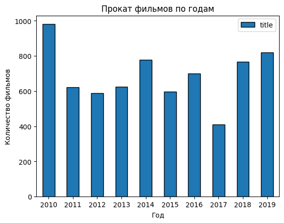

```python
# построим сводную таблицу
# сгруппируем количество строк с названиями фильмов по каждому году премьеры фильма
release_title_count = good_mkrf.pivot_table(index='release_year', values='title', aggfunc='count')

# построим столбчатую диаграмму методом plot
release_title_count.plot(kind='bar', edgecolor='black')

# обозначим заголовок
# назовём оси 'x' и 'y'
# повернём подписи на оси 'x'
plt.title('Прокат фильмов по годам')
plt.xlabel('Год')
plt.ylabel('Количество фильмов')
plt.xticks(rotation=1)

# выведем диаграмму на экран
plt.show()
```

Согласно диаграмме без учёта данных в столбце с кассовыми сборами:

- Самое большое количество фильмов вышло в 2010 году — около 1000.
- Самое маленькое количество фильмов вышло в 2017 году — около 400.

Предположим, что фильм точно вышел в прокат, если заполнен столбец со сборами — `box_office`. Построим столбчатую диаграмму, чтобы наглядно изобразить количество фильмов в прокате за каждый год:

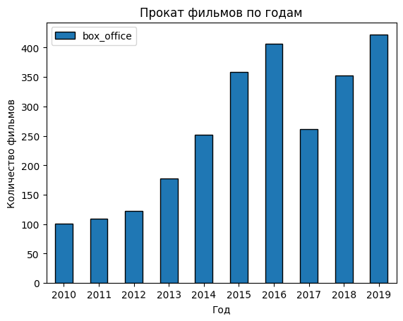

```python
# построим сводную таблицу
# сгруппируем количество строк со сборами в рублях по каждому году премьеры фильма
release_box_office_count = good_mkrf.pivot_table(index='release_year', values='box_office', aggfunc='count')

# построим столбчатую диаграмму методом plot
release_box_office_count.plot(kind='bar', edgecolor='black')

# обозначим заголовок диаграммы
# назовём оси 'x' и 'y'
# повернём подписи на оси 'x'
plt.title('Прокат фильмов по годам')
plt.ylabel('Количество фильмов')
plt.xlabel('Год')
plt.xticks(rotation=1)

# выведем диаграмму на экран
plt.show()
```

Рассчитаем конверсию и посмотрим, какую долю составляют фильмы с указанной информацией о сборах от общего количества фильмов:

```python
# разделим количество фильмов с данными в box_office на общее количество фильмов
box_office_share = good_mkrf['box_office'].count() / good_mkrf['title'].count()

# выведем результат на экран
print('Доля фильмов с указанной информацией о прокате в кинотеатрах:', (box_office_share*100).round(1), '%')
```

```
Доля фильмов с указанной информацией о прокате в кинотеатрах: 37.2 %
```

Рассчитаем конверсию фильмов со сборами в зависимости от года:

```python
# c помощью pivot_table найдём количество фильмов со сборами в зависимости от года
# найдём общее количество фильмов  в зависимости от года
box_office_title_count = good_mkrf.pivot_table(
    index='release_year',
    values=['box_office', 'title'],
    aggfunc={'box_office':'count', 'title':'count'}
)

# рассчитаем долю, умножим на 100 и округлим результат до 1 знака после запятой
movie_release_year_share = ((box_office_title_count['box_office'] / box_office_title_count['title'])*100).round(1)

# проверим результат
movie_release_year_share
```

```
release_year
2010    10.3
2011    17.5
2012    20.9
2013    28.5
2014    32.3
2015    59.9
2016    58.2
2017    63.9
2018    45.8
2019    51.5
dtype: Float64
```

Представим информацию более наглядно, построим график изменения доли фильмов со сборами для каждого года:

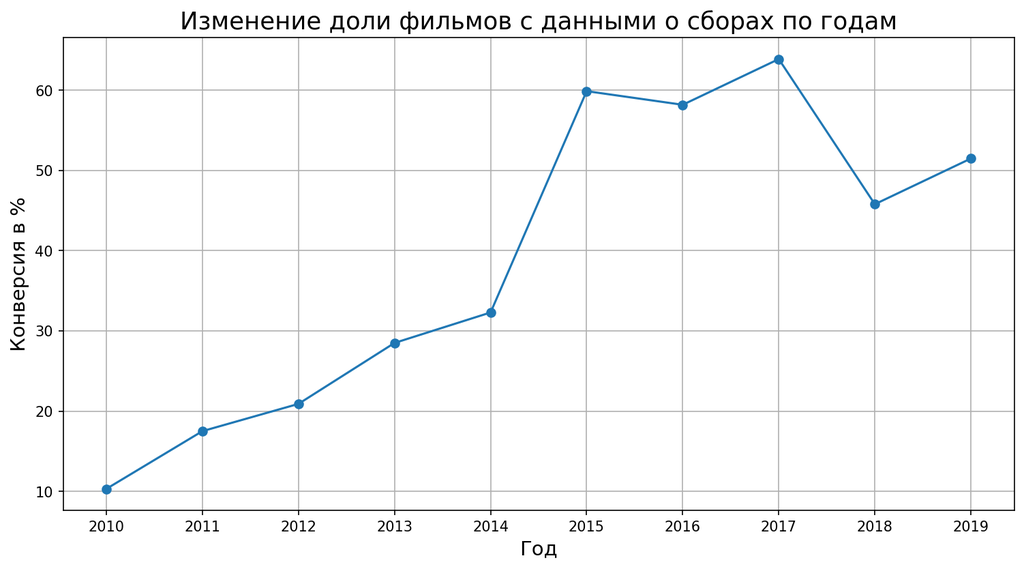

```python
# построим график с помощью метода plot()
movie_release_year_share_plot = movie_release_year_share.plot(grid=True, figsize=(12, 6), style='o-')

# добавим все года на ось абсцисс
movie_release_year_share_plot.set_xticks(movie_release_year_share.index)

# добавим заголовок, название осей 'y' и 'x'
# настроим их размер с помощью fontsize
movie_release_year_share_plot.set_title('Изменение доли фильмов с данными о сборах по годам', fontsize=17)
movie_release_year_share_plot.set_ylabel('Конверсия в %', fontsize=14)
movie_release_year_share_plot.set_xlabel('Год', fontsize=14)

# установим более высокое разрешение
plt.gcf().set_dpi(150)
```

- На графике видно, что полнее всего представлен в данных период `с 2015 до 2017 года`. Доля достигла максимального значения в этот отрезок времени, сначала **59.9 %** `в 2015`, затем — **63.9 %** `в 2017 году`.
- `До 2018 года` доля стремительно уменьшалась и достигла значения — **45.8 %**.

### Анализ изменения динамики проката по годам

- Посмотрим на минимальную и максимальную сумма сборов в каждом году.
- Посмотрим, в каком году сумма сборов была минимальной и максимальной.
- Посчитаем среднюю и медианную сумму сборов для каждого года.

```python
# с помощью сводной таблицы выведем максимальную и минимальную сумму в каждом году
min_max_release_year = good_mkrf.pivot_table(index='release_year', values='box_office', aggfunc=['min', 'max'])

# проверим результат
min_max_release_year
```

| release_year | min box_office | max box_office |
| --- | --- | --- |
| 2010 | 75 | 1446400 |
| 2011 | 125 | 11618085 |
| 2012 | 80 | 2311220 |
| 2013 | 40 | 4321638 |
| 2014 | 50 | 50987664 |
| 2015 | 100 | 59524891 |
| 2016 | 200 | 57783155 |
| 2017 | 7900 | 57293208 |
| 2018 | 41225 | 59431246 |
| 2019 | 4398 | 58778318 |

- Минимальная сумма сборов зафиксирована `в 2013 году` - всего лишь `40 рублей`.
- Максимальная сумма сборов — `в 2015 году`, `59 524 891 рублей`.

Для большей наглядности построим линейный график:

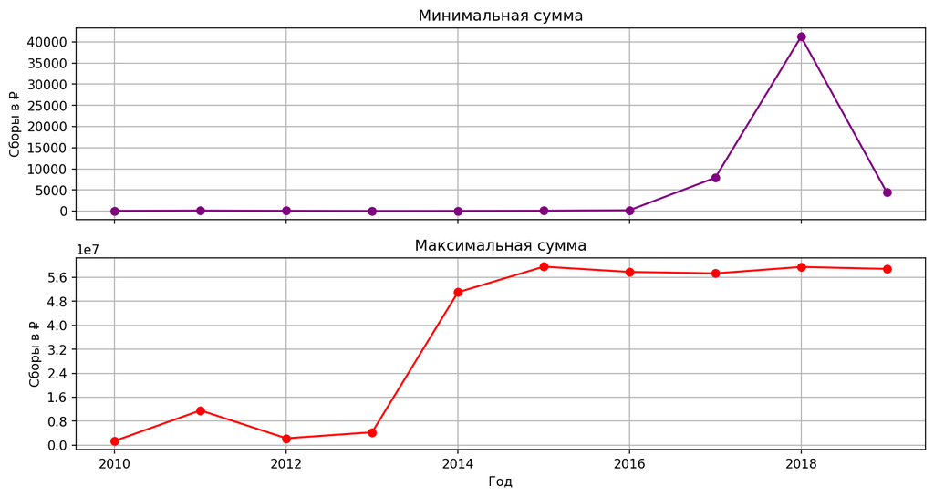

```python
# импортируем класс MaxNLocator для управления количеством меток на оси
from matplotlib.ticker import MaxNLocator

# создадим две оси на одном графике с помощью plt.subplots()
# создадим два графика, расположенных вертикально
# зададим размер фигуры
# сделаем ось 'x' общей для обоих графиков
fig, axes = plt.subplots(2, 1, figsize=(12, 6), sharex=True)

# построим график с минимальными значениями
axes[0].plot(min_max_release_year.index, min_max_release_year['min'], marker='o', linestyle='-', color='purple')
axes[0].set_title('Минимальная сумма')
axes[0].set_ylabel('Сборы в ₽')
axes[0].yaxis.set_major_locator(MaxNLocator(nbins=10))
axes[0].grid(True)

# построим график с максимальными значениями
axes[1].plot(min_max_release_year.index, min_max_release_year['max'], marker='o', linestyle='-', color='red')
axes[1].set_title('Максимальная сумма')
axes[1].set_ylabel('Сборы в ₽')
axes[1].set_xlabel('Год')
axes[1].yaxis.set_major_locator(MaxNLocator(nbins=10))
axes[1].grid(True)

# установим более высокое разрешение
plt.gcf().set_dpi(150)
```

- В `2017 году` виден занчительный рост минимальной суммы кассовых сборов. В период `с 2017 до 2018 года` произошёл резкий подъём с `7 900 до 41 225 рублей` и резкий спад `с 2018 до 2019 года` — сумма уменьшилась практически в 9 раз, `до 4 398 рублей`.
- В период `с 2010 до 2011 года` наблюдается рост максимальной суммы сборов `с 1 446 400 до 11 618 085 рублей`. Заметен резкий скачок вверх в период `с 2013 до 2014 года - с 4 321 638 до 50 987 664 рублей`. Далее сумма остаётся высокой на стабильном уровне без сильных изменений, варьируется `от 57 293 208 до 59 524 891 рублей`.

Рассчитаем среднюю сумму сборов для каждого года:

```python
# рассчитаем среднюю сумму с помощью pivot_table()
mean_box_office = good_mkrf.pivot_table(index='release_year', values='box_office')

# выведем результат на экран
mean_box_office
```

| release_year | box_office |
| --- | --- |
| 2010 | 24046.079208 |
| 2011 | 129383.165138 |
| 2012 | 56548.154472 |
| 2013 | 55295.932584 |
| 2014 | 1865091.694444 |
| 2015 | 8828424.198324 |
| 2016 | 7578160.194103 |
| 2017 | 10216785.328244 |
| 2018 | 9771050.289773 |
| 2019 | 8600544.625592 |

Рассчитаем медианную сумму сборов для каждого года:

```python
# рассчитаем медианную сумму с помощью pivot_table
median_box_office = good_mkrf.pivot_table(index='release_year', values='box_office', aggfunc='median')

# проверим результат
median_box_office
```

| release_year | box_office |
| --- | --- |
| 2010 | 1710.0 |
| 2011 | 3000.0 |
| 2012 | 6220.0 |
| 2013 | 3565.0 |
| 2014 | 16232.5 |
| 2015 | 2238500.5 |
| 2016 | 1735813.0 |
| 2017 | 4731709.0 |
| 2018 | 4601725.5 |
| 2019 | 2819216.0 |

Для более комфортного восприятия построим линейные графики и сравним результат расчётов:

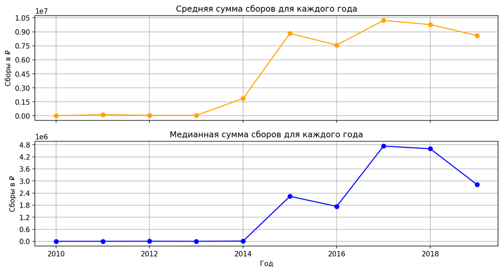

```python
# создадим две оси на одном графике с помощью plt.subplots()
# создадим два графика, расположенных вертикально
# зададим размер фигуры
# сделаем ось 'x' общей для обоих графиков
fig, axes = plt.subplots(2, 1, figsize=(12, 6), sharex=True)

# построим график для средней суммы сборов
axes[0].plot(mean_box_office, marker='o', linestyle='-', color='orange')
axes[0].set_title('Средняя сумма сборов для каждого года')
axes[0].set_ylabel('Сборы в ₽')
axes[0].yaxis.set_major_locator(MaxNLocator(nbins=10))
axes[0].grid(True)

# построим график для медианной суммы сборов
axes[1].plot(median_box_office, marker='o', linestyle='-', color='blue')
axes[1].set_title('Медианная сумма сборов для каждого года')
axes[1].set_xlabel('Год')
axes[1].set_ylabel('Сборы в ₽')
axes[1].yaxis.set_major_locator(MaxNLocator(nbins=10))
axes[1].grid(True)

# установим более высокое разрешение
plt.gcf().set_dpi(150)
```

- Средняя сумма сборов начала заметно расти в период `с 2013 до 2014 года`, далее виден резкий подъём `с 2014 по 2015 год` — **с 1 865 091 до 8 828 424 ₽**. `До 2016` года значение опустилось **до 7 578 160 ₽**, `в 2017` снова возросло и достигло максимума — **10 216 785**. Далее сумма плавно опустилась **до 8 600 544 ₽**.
- В отличие от среднего значения, на графике с медианной суммой не наблюдается ощутимого роста в период `с 2013 до 2014 года`, однако виден резкий подъём с `с 2014 по 2015 год` — **с 16 232 до 2 238 500 ₽**. Далее значение аналогично опускается `до 2016 года`, но на меньшую сумму — **1 735 813 ₽**. В 2017 году максимальная сумма составила **4 731 709**. Виден резкий спад с 2018 по 2019 год — до **2 819 216 ₽**.

Значения на двух графиках существенно отличаются друг от друга. Мы будем полагаться на результаты расчётов медианной суммы, так как медиана более устойчива к выбросам, чем среднее.

**Выводы:**

- Минимальная сумма сборов — в 2013 году, 40 рублей.
- Максимальная сумма сборов — в 2015 году, 59 524 891 рублей.
- С 2010 по 2014 год наблюдается значительный рост максимальных сборов, после чего сумма стабилизируется, а минимальные сборы резко поднимаются в 2017–2018 годах, но в 2019 году падают почти в 9 раз.
- Средняя и медианная суммы сборов показывают схожую динамику роста и спада, но отличие в 2013–2014 годах указывает на влияние выбросов. Также значительно отличается сумма сборов для каждого года. Медиана более устойчива к выбросам и лучше отражает общий тренд.

### Анализ взаимосвязи между возрастным ограничением и сборами фильмов в прокате

Определим, влияет ли возрастное ограничение аудитории («6+», «12+», «16+», «18+» и т. д.) на сборы фильма в прокате в период с 2015 по 2019 год:

- Посмотрим, фильмы с каким возрастным ограничением собрали больше всего денег в прокате.
- Изучим, меняется ли картина в зависимости от года.

Посмотрим, фильмы для какой возрастной группы собрали больше всего денег в прокате независимо от года проката:

```python
# построим сводную таблицу и рассчитаем сумму сборов для каждой возрастной группы
good_mkrf.pivot_table(index='age_restriction', values='box_office', aggfunc='sum').sort_values(by='box_office', ascending=False)
```

| age_restriction | box_office |
| --- | --- |
| 6 - 12 лет | 7336506871 |
| от 18 лет | 7044488617 |
| 12 - 16 лет | 1742118873 |
| 0 - 6 лет | 370742616 |

- Независимо от года проката, самую большую сумму в прокате собрали фильмы с возрастным ограничением `6 - 12 лет` — **7 336 506 871**, а минимальную сумму `0 - 6 лет`— **370 742 616**.

Выберем строки в датафрейме с информацией о фильмах с годом проката — `от 2015 до 2019`:

```python
# отфильтруем фильмы с годом проката от 2015 до 2019
release_year_query = good_mkrf.query('release_year >= 2015 and release_year <= 2019')

# проверим результат
release_year_query.head()
```

|  | title | pu_number | show_start_date | type | film_studio | production_country | director | producer | age_restriction | refundable_support | nonrefundable_support | budget | financing_source | ratings | genres | box_office | release_year | main_director | main_genre | state_support_share_% |
| --- | --- | --- | --- | --- | --- | --- | --- | --- | --- | --- | --- | --- | --- | --- | --- | --- | --- | --- | --- | --- |
| 6 | небесный верблюд | 111000115 | 2015-01-14 12:00:00+00:00 | Художественный | ооо продюсерский центр "всё хорошо" | Россия | Ю.Фетинг | И.Плиско | 0 - 6 лет | 0 | 34000000 | 49280496 | Министерство культуры | 6.7 | детский,семейный | 61040 | 2015 | Ю.Фетинг | детский | 69.0 |
| 8 | после тебя | 111000117 | 2017-01-10 12:00:00+00:00 | Художественный | компания production value worldwide (ооо "прод... | Россия | А.Безрукова (псевдоним - Анна Матисон) | С.Безруков | 6 - 12 лет | 7000000 | 20000000 | 45483233 | Министерство культуры, Фонд кино | 6.7 | драма | 12260956 | 2017 | А.Безрукова (псевдоним - Анна Матисон) | драма | 59.4 |
| 10 | пилигрим | 111000119 | 2019-02-14 12:00:00+00:00 | Художественный | ооо "чайка синема" | Россия | А.Баршак | М.Гуцериев, Е.Север, Т.Стацман | 6 - 12 лет | 0 | 35000000 | 115000000 | Министерство культуры | 5.3 | триллер | 4293650 | 2019 | А.Баршак | триллер | 30.4 |
| 16 | библиотекарь | 111000215 | 2015-01-14 12:00:00+00:00 | Художественный | ооо "россфильм" | Россия | Т.Воронецкая | Е.Белова | 6 - 12 лет | <NA> | <NA> | <NA> | неизвестно | 6.7 | фэнтези,боевик,триллер | <NA> | 2015 | Т.Воронецкая | фэнтези | NaN |
| 17 | городские птички | 111000216 | 2016-01-15 12:00:00+00:00 | Художественный | ооо "каргофильм" | Россия | Ю.Белюсева | А.Готлиб | 6 - 12 лет | 0 | 25000000 | 38461538 | Министерство культуры | 5.4 | комедия,мелодрама | 355567 | 2016 | Ю.Белюсева | комедия | 65.0 |

Посмотрим, фильмы для какой возрастной группы собрали больше всего денег в прокате в период `с 2015 по 2019`:

```python
# построим сводную таблицу для расчётов
release_year_query.pivot_table(index=['age_restriction'], values='box_office', aggfunc='sum').sort_values(by='box_office', ascending=False)
```

| age_restriction | box_office |
| --- | --- |
| 6 - 12 лет | 7210039571 |
| от 18 лет | 6885482394 |
| 12 - 16 лет | 1606696451 |
| 0 - 6 лет | 288305936 |

- В период `с 2015 по 2019` год больше всего денег собрали фильмы с ограничением `6 - 12 лет` — **7 210 039 571**, меньше всего `0 - 6 лет` — **288 305 936**.

Построим сводную таблицу, рассчитаем сумму сборов для каждого возрастного ограничения за каждый год в период `с 2015 по 2019`:

```python
# построим сводную таблицу для расчётов и сохраним результат
age_restriction_year_box_office_sum = release_year_query.pivot_table(
    index=['age_restriction', 'release_year'],
    values='box_office',
    aggfunc='sum'
)

# проверим результат
age_restriction_year_box_office_sum.sort_values(by='box_office', ascending=False)
```

| age_restriction | release_year | box_office |
| --- | --- | --- |
| от 18 лет | 2019 | 1647660090 |
| 6 - 12 лет | 2018 | 1607541792 |
| от 18 лет | 2018 | 1603639398 |
| 6 - 12 лет | 2019 | 1527089754 |
|  | 2016 | 1485281226 |
|  | 2015 | 1416988759 |
| от 18 лет | 2015 | 1249389596 |
|  | 2016 | 1194429190 |
|  | 2017 | 1190364120 |
| 6 - 12 лет | 2017 | 1173138040 |
| 12 - 16 лет | 2019 | 436933922 |
|  | 2015 | 364702212 |
|  | 2016 | 319105955 |
|  | 2017 | 290174852 |
|  | 2018 | 195779510 |
| 0 - 6 лет | 2015 | 129495296 |
|  | 2016 | 85494828 |
|  | 2018 | 32449002 |
|  | 2017 | 23120744 |
|  | 2019 | 17746066 |

- Наибольшие кассовые сборы зафиксированы у фильмов с рейтингом `от 18 лет` в `2019 году` — **1 647 660 090 ₽**.
- Далее идут фильмы с категорией `6 - 12 лет` в `2018 году` с **1 607 541 792 ₽**.
- Категория `12–16 лет` собрала значительно меньше денег. Максимальное значение в `2019 году` — **436 933 922 ₽**. При этом сумма постепенно снижалась `с 2015 по 2018 год`.
- Фильмы для самой младшей аудитории `0–6 лет` имеют наименьшие сборы, с максимальным значением в `2015 году` **129 495 296 ₽** и резким падением в `2019 году` — до **17 746 066**.

Динамика кассовых сборов по годам в зависимости от рейтингов фильмов может быть связана с изменением предпочтений аудитории, маркетинговыми стратегиями и экономическими факторами, а также с популярностью жанров.

**Выводы:**

- Возрастное ограничение фильмов влияет на кассовые сборы.
- Наибольшие суммы в период с 2015 по 2019 год собрали картины для аудитории 6–12 лет.
- Фильмы 18+ также показали высокие результаты, особенно в 2019 году, тогда как проекты для зрителей младше 6 лет стабильно приносили наименьшие доходы.
- Динамика сборов может быть обусловлена изменением предпочтений зрителей, маркетинговыми стратегиями и общей ситуацией в индустрии кино.